# Project2-DataScience

Abanoub Mimi, Amir George, Tony Foti

May 8, 2016

# Initial exploration (Amir)

We begin by attaching required libraries and loading the datasets and relevant classifiers.

```r
library(dplyr)
library(knitr)
library(RWeka)
library(tidyr)
library(ggplot2)
```

```r
trainDf <- read.csv('data/train.csv')
testDf <- read.csv('data/test.csv')
contractRefDf <- read.csv('data/contract_ref.csv')
calendarRefDf <- read.csv('data/calendar_ref.csv')
dailyAggDf <- read.csv('data/daily_aggregate.csv')
roamingDf <- read.csv('data/roaming_monthly.csv')
```

```r
trainDf$TARGET <- as.factor(trainDf$TARGET)
RF <- make_Weka_classifier("weka/classifiers/trees/RandomForest")
NB <- make_Weka_classifier("weka/classifiers/bayes/NaiveBayes")
MLP <- make_Weka_classifier("weka/classifiers/functions/MultilayerPerceptron")
```

## Train and Test datasets

We proceed by taking a look at the training and test datasets:

```r
trainDf %>% dim
```

```
## [1] 75422    12
```

```r
trainDf$CONTRACT_KEY %>% unique %>% length
```

```
## [1] 75422
```

```r
trainDf %>% summary
```

```
##   CONTRACT_KEY       X206_SESSION_COUNT   X206_USAGE
##  Min.   :142404951   Min.   :    1.0    Min.   :     0
##  1st Qu.:145462942   1st Qu.:   72.0    1st Qu.:    31
##  Median :149272192   Median :  226.0    Median :   504
##  Mean   :149032149   Mean   :  564.6    Mean   :  1646
##  3rd Qu.:152434408   3rd Qu.:  615.0    3rd Qu.:  1806
##  Max.   :156233277   Max.   :21711.0    Max.   :217661
##  X207_SESSION_COUNT   X207_USAGE     X208_SESSION_COUNT   X208_USAGE
##  Min.   :    1.0    Min.   :     0   Min.   :    1.0    Min.   :     0
##  1st Qu.:   76.0    1st Qu.:    46   1st Qu.:   77.0    1st Qu.:    69
##  Median :  236.0    Median :   591   Median :  226.0    Median :   635
##  Mean   :  595.7    Mean   :  1680   Mean   :  653.4    Mean   :  1774
##  3rd Qu.:  648.0    3rd Qu.:  1873   3rd Qu.:  617.0    3rd Qu.:  1940
##  Max.   :25075.0    Max.   :184156   Max.   :34566.0    Max.   :279969
##  X209_SESSION_COUNT   X209_USAGE     X210_SESSION_COUNT   X210_USAGE
##  Min.   :    1.0    Min.   :     0   Min.   :    1.0    Min.   :     0
##  1st Qu.:   77.0    1st Qu.:    74   1st Qu.:   72.0    1st Qu.:    65
##  Median :  220.0    Median :   630   Median :  214.0    Median :   605
##  Mean   :  631.5    Mean   :  1835   Mean   :  637.3    Mean   :  1751
##  3rd Qu.:  599.0    3rd Qu.:  1976   3rd Qu.:  598.0    3rd Qu.:  1897
##  Max.   :37338.0    Max.   :229770   Max.   :35808.0    Max.   :249308
##  TARGET
##  0:60245
##  1:15177
##
##
##
##
```

```r
sapply(trainDf, function(x) sum(is.na(x)))
```

```
##       CONTRACT_KEY X206_SESSION_COUNT         X206_USAGE
##                  0                  0                  0
## X207_SESSION_COUNT         X207_USAGE X208_SESSION_COUNT
##                  0                  0                  0
##         X208_USAGE X209_SESSION_COUNT         X209_USAGE
##                  0                  0                  0
## X210_SESSION_COUNT         X210_USAGE             TARGET
##                  0                  0                  0
```

```r
testDf %>% dim
```

```
## [1] 32321    11
```

```r
testDf$CONTRACT_KEY %>% unique %>% length
```

```
## [1] 32321
```

```r
testDf %>% summary
```

```
##   CONTRACT_KEY       X206_SESSION_COUNT   X206_USAGE
##  Min.   :142404960   Min.   :    1.0    Min.   :     1
##  1st Qu.:145462181   1st Qu.:   73.0    1st Qu.:    33
##  Median :149187079   Median :  226.0    Median :   520
##  Mean   :149016819   Mean   :  568.3    Mean   :  1673
##  3rd Qu.:152432330   3rd Qu.:  614.0    3rd Qu.:  1831
##  Max.   :156233408   Max.   :37245.0    Max.   :172834
##  X207_SESSION_COUNT   X207_USAGE     X208_SESSION_COUNT   X208_USAGE
##  Min.   :    1.0    Min.   :     0   Min.   :    1.0    Min.   :     1
##  1st Qu.:   76.0    1st Qu.:    48   1st Qu.:   78.0    1st Qu.:    70
##  Median :  238.0    Median :   585   Median :  227.0    Median :   644
##  Mean   :  599.5    Mean   :  1718   Mean   :  659.3    Mean   :  1829
##  3rd Qu.:  649.0    3rd Qu.:  1886   3rd Qu.:  624.0    3rd Qu.:  1978
##  Max.   :27507.0    Max.   :247282   Max.   :27753.0    Max.   :274432
##  X209_SESSION_COUNT   X209_USAGE     X210_SESSION_COUNT   X210_USAGE
##  Min.   :    1.0    Min.   :     1   Min.   :    1.0    Min.   :     1
##  1st Qu.:   76.0    1st Qu.:    70   1st Qu.:   72.0    1st Qu.:    63
##  Median :  219.0    Median :   634   Median :  213.0    Median :   609
##  Mean   :  635.8    Mean   :  1897   Mean   :  643.3    Mean   :  1793
##  3rd Qu.:  596.0    3rd Qu.:  2003   3rd Qu.:  602.0    3rd Qu.:  1911
##  Max.   :26071.0    Max.   :205225   Max.   :25435.0    Max.   :244814
```

```r
sapply(testDf, function(x) sum(is.na(x)))
```

```
##       CONTRACT_KEY X206_SESSION_COUNT         X206_USAGE
##                  0                  0                  0
## X207_SESSION_COUNT         X207_USAGE X208_SESSION_COUNT
##                  0                  0                  0
##         X208_USAGE X209_SESSION_COUNT         X209_USAGE
##                  0                  0                  0
## X210_SESSION_COUNT         X210_USAGE
##                  0                  0
```

There are no NA values in the original train and test datasets, and no multiple observations for the same `CONTRACT_KEY`. Now, we proceed by temporarily adding two features to both datasets, and deriving some insight from them.

```r
tmpTrain <- trainDf
tmpTest <- testDf
trainDf <- trainDf %>% mutate(TOTAL_USAGE = X206_USAGE + X207_USAGE + X208_USAGE + X209_USAGE + X210_USAGE, TOTAL_SESSION_COUNT = X206_SESSION_COUNT + X207_SESSION_COUNT + X208_SESSION_COUNT + X209_SESSION_COUNT + X210_SESSION_COUNT)
testDf <- testDf %>% mutate(TOTAL_USAGE = X206_USAGE + X207_USAGE + X208_USAGE + X209_USAGE + X210_USAGE, TOTAL_SESSION_COUNT = X206_SESSION_COUNT + X207_SESSION_COUNT + X208_SESSION_COUNT + X209_SESSION_COUNT + X210_SESSION_COUNT)
```

Now we define two helper functions. The function `targetPercentCalculator` returns the percentage of users in the trainDf between a given minimum and maximum thresholds for total usage, that have the input target (0 or 1).

```r
targetPercentCalculator <- function(target, minThreshold, maxThreshold) {
  tmp <- trainDf %>% filter(TOTAL_USAGE > minThreshold & TOTAL_USAGE < maxThreshold) %>% group_by(TARGET) %>% summarize(sum=n())
  tmp[tmp$TARGET==target,"sum"][[1]] * 100 / (tmp[tmp$TARGET==1 - target,"sum"][[1]] + tmp[tmp$TARGET==target,"sum"][[1]])
}
```

The function `usagePercentCalculator` returns the percentage of users from the trainDf whose user consumption is between the given thresholds.

```r
usagePercentCalculator <- function(minThreshold, maxThreshold) {
  (trainDf %>% filter(TOTAL_USAGE > minThreshold & TOTAL_USAGE < maxThreshold ) %>% nrow) * 100 / (trainDf %>% nrow)
}
```

Now using the previous two functios, we take a look at some properties of the data:

```r
targetPercentCalculator(0,0,100)
```

```
## [1] 99.58602
```

```r
usagePercentCalculator(0,100)
```

```
## [1] 16.65429
```

Users whose total consumption is betweeen 0 and 100 MB make about 17% of the train data, and 99.6% of them have target 0.

```r
targetPercentCalculator(0,0,500)
```

```
## [1] 98.65437
```

```r
usagePercentCalculator(0,500)
```

```
## [1] 23.15505
```

Users whose total consumption is betweeen 0 and 500 MB make about 23% of the train data, and 98.65% of them have target 0.

```r
targetPercentCalculator(0,0,2000)
```

```
## [1] 95.51325
```

```r
usagePercentCalculator(0,2000)
```

```
## [1] 39.62769
```

Users whose total consumption is betweeen 0 and 2000 MB make about 40% of the train data, and 95.5% of them have target 0.

```r
targetPercentCalculator(0,0,5000)
```

```
## [1] 90.38666
```

```r
usagePercentCalculator(0,5000)
```

```
## [1] 57.3334
```

Users whose total consumption is betweeen 0 and 5000 MB make about 57% of the train data, and 90% of them have target 0.

```r
trainDf <- tmpTrain
testDf <- tmpTest
rm(tmpTrain, tmpTest)
```

## ContractRef dataset

We now proceed with examiming the `contract_ref` dataset.

```r
contractRefDf %>% dim
```

```
## [1] 107743      6
```

```r
contractRefDf$CONTRACT_KEY %>% unique %>% length
```

```
## [1] 107743
```

No multiple observations for the same `CONTRACT_KEY`.

```r
sapply(contractRefDf, function(x) sum(is.na(x)))
```

```
##  CONTRACT_KEY           AGE        GENDER     RATE_PLAN VALUE_SEGMENT
##             0             0             0             0             6
##  HANDSET_NAME
##             0
```

```r
contractRefDf %>% summary
```

```
##   CONTRACT_KEY            AGE                 GENDER
##  Min.   :142404951   Min.   :-29.00   Not Entered:54379
##  1st Qu.:145462648   1st Qu.: 36.00   Male       :25064
##  Median :149270714   Median : 61.00   M          :17499
##  Mean   :149027550   Mean   : 67.55   Female     : 5510
##  3rd Qu.:152433554   3rd Qu.: 99.00   Unknown    : 3148
##  Max.   :156233408   Max.   : 99.00   F          : 1468
##                                       (Other)    :  675
##                          RATE_PLAN      VALUE_SEGMENT
##  Enterprise Shared Data Bundle:14155   Core    :48031
##  2013 Business El Asly 30     : 8696   High    :21666
##  Business Flex 35             : 8046   Med-Low :12992
##  2014 ElAsly Plus 35          : 7039   Med-High:12577
##  Red 150                      : 5456   N/A     : 8169
##  2014 Flex 40 CL 50           : 3583   (Other) : 4302
##  (Other)                      :60768   NA's    :    6
##                           HANDSET_NAME
##  Fibocom Wireless G610          : 9980
##  Vodafone K4201-Z               : 4660
##  Apple iPhone 6                 : 4139
##  Apple iPhone 5S                : 2341
##  Apple iPhone 6 Plus            : 2025
##  Samsung Galaxy Grand Prime DUOS: 1774
##  (Other)                        :82824
```

Some weird observations are spotted in this examination: ### Unnaturally small age values

```r
contractRefDf[contractRefDf$AGE < 15,]
```

```
##        CONTRACT_KEY AGE      GENDER                  RATE_PLAN
## 2024      150356809   2        Male        2014 ElAsly Plus 35
## 5183      150283660 -29     Unknown           Unified USB 7 GB
## 6741      143317098   1 Not Entered Business USB 250 unlimited
## 14526     149894257 -29     Unknown            Red 150 Control
## 23424     147065280   4        Male           Vodafone Easy 50
## 23585     147780031   1 Not Entered       2012 Bouquet Ctrl 25
## 56035     150283661 -29     Unknown           Unified USB 7 GB
## 58577     147780020   1 Not Entered       2012 Bouquet Ctrl 25
## 68429     149891714   2           M           Business Flex 30
## 71211     147780161   1 Not Entered       2012 Bouquet Ctrl 25
## 74516     149186171 -16        Male          Unified USB 12 GB
## 84383     150283618 -29     Unknown        Unified USB 1.25 GB
## 100061    149432741   1 Not Entered          Unified USB 20 GB
##        VALUE_SEGMENT                    HANDSET_NAME
## 2024            Core        Samsung Galaxy S III Neo
## 5183        Med-High                Vodafone K4201-Z
## 6741            High                Vodafone K4201-Z
## 14526           High               Samsung Galaxy S4
## 23424           Core                 Apple iPhone 5S
## 23585        Med-Low                     Lenovo S850
## 56035       Med-High                  Vodafone K3765
## 58577           Core         HTC Desire 616 dual sim
## 68429           Core Samsung Galaxy Grand Prime DUOS
## 71211        Med-Low
## 74516           High                Vodafone K4201-Z
## 84383           Core                  Vodafone K3765
## 100061          High                    Huawei K3770
```

### Age values of `99`

```r
contractRefDf[contractRefDf$AGE == 99,] %>% nrow
```

```
## [1] 51263
```

Almost half the observations in this dataset (51263 out of 107743) have an age value of `99`, which could be a default value for unknown or not entered ages.

### Incomplete `GENDER` observations

More than half the oservations (54379 out of 107743) have missing gender values labeled as `Not Entered`, while 3148 observations have gender values labeled as `Unknown`.

```r
length(intersect(unique(trainDf$CONTRACT_KEY),unique(contractRefDf[contractRefDf$GENDER == "Not Entered",]$CONTRACT_KEY)))
```

```
## [1] 38105
```

```r
length(intersect(unique(testDf$CONTRACT_KEY),unique(contractRefDf[contractRefDf$GENDER == "Not Entered",]$CONTRACT_KEY)))
```

```
## [1] 16274
```

The missing observations are not tied to customers of train dataset only or test dataset only as shown above.

```r
contractRefDf$GENDER %>% unique
```

```
## [1] Male        Female      Not Entered M           Unknown     F
## [7] m           f
## Levels: f F Female m M Male Not Entered Unknown
```

Moreover, the male gender has multiple labels (`Male`, `M` & `m`), as well as the female gender (`Female`, `F` & `f`).

### NAs in `VALUE_SEGMENT`

There are 6 NA observations in the `VALUE_SEGMENT` column, as well as 8169 values of “N/A” which are basically the same as NA values. So, these are all missing values.

## Roaming dataset

```r
roamingDf %>% dim
```

```
## [1] 3946    4
```

```r
roamingDf$CONTRACT_KEY %>% unique %>% length
```

```
## [1] 2374
```

```r
roamingDf %>% summary
```

```
##   CONTRACT_KEY       CALL_MONTH_KEY      USAGE         SESSION_COUNT
##  Min.   :142405434   Min.   :206.0   Min.   :   0.00   Min.   :   1.0
##  1st Qu.:146464764   1st Qu.:207.0   1st Qu.:   5.00   1st Qu.:   8.0
##  Median :150003226   Median :208.0   Median :  34.00   Median :  41.0
##  Mean   :149744551   Mean   :208.1   Mean   :  87.57   Mean   : 119.3
##  3rd Qu.:153203930   3rd Qu.:209.0   3rd Qu.: 121.75   3rd Qu.: 146.8
##  Max.   :156232983   Max.   :210.0   Max.   :1352.00   Max.   :1695.0
```

```r
sapply(roamingDf, function(x) sum(is.na(x)))
```

```
##   CONTRACT_KEY CALL_MONTH_KEY          USAGE  SESSION_COUNT
##              0              0              0              0
```

No weird observations here. The number of observations is greater than the number of unique customers because each customer can have multiple entries concerning different months.

## CalendarRef dataset

```r
calendarRefDf %>% dim
```

```
## [1] 183   6
```

```r
calendarRefDf$DATE_KEY %>% unique %>% length
```

```
## [1] 183
```

```r
calendarRefDf %>% summary
```

```
##     DATE_KEY         FULL_DATE        DAY_NAME  WEEKDAY_FLAG
##  Min.   :6214   2015-10-01:  1   Friday   :26   N: 52
##  1st Qu.:6260   2015-10-02:  1   Monday   :26   Y:131
##  Median :6305   2015-10-03:  1   Saturday :26
##  Mean   :6305   2015-10-04:  1   Sunday   :26
##  3rd Qu.:6350   2015-10-05:  1   Thursday :27
##  Max.   :6396   2015-10-06:  1   Tuesday  :26
##                 (Other)   :177   Wednesday:26
##    MONTH_KEY        MONTH_NAME
##  Min.   :206.0   December:31
##  1st Qu.:207.0   February:29
##  Median :208.0   January :31
##  Mean   :208.5   March   :31
##  3rd Qu.:210.0   November:30
##  Max.   :211.0   October :31
##
```

```r
sapply(calendarRefDf, function(x) sum(is.na(x)))
```

```
##     DATE_KEY    FULL_DATE     DAY_NAME WEEKDAY_FLAG    MONTH_KEY
##            0            0            0            0            0
##   MONTH_NAME
##            0
```

An interesting observation here is that there are 183 different dates although we only need 29 dates representing the last month in our data which is February 2016.

## Daily aggregate dataset

```r
dailyAggDf %>% dim
```

```
## [1] 4985457       6
```

```r
dailyAggDf$CONTRACT_KEY %>% unique %>% length
```

```
## [1] 30995
```

```r
length(intersect(unique(trainDf$CONTRACT_KEY),unique(dailyAggDf$CONTRACT_KEY)))
```

```
## [1] 21708
```

```r
length(intersect(unique(testDf$CONTRACT_KEY),unique(dailyAggDf$CONTRACT_KEY)))
```

```
## [1] 9287
```

```r
dailyAggDf %>% summary
```

```
##   CONTRACT_KEY       CALL_DATE_KEY     CELL_KEY        ROAMING_FLAG
##  Min.   :142404951   Min.   :6337   Min.   :    890   LOCAL  :4824826
##  1st Qu.:146824459   1st Qu.:6344   1st Qu.:6795060   ROAMING: 160631
##  Median :149994180   Median :6351   Median :6812104
##  Mean   :149715056   Mean   :6351   Mean   :6805081
##  3rd Qu.:152676589   3rd Qu.:6358   3rd Qu.:6836445
##  Max.   :156233408   Max.   :6365   Max.   :6871894
##  TOTAL_CONSUMPTION   NO_OF_SESSIONS
##  Min.   :0.000e+00   Min.   :   1.000
##  1st Qu.:1.536e+05   1st Qu.:   1.000
##  Median :1.004e+06   Median :   1.000
##  Mean   :1.745e+07   Mean   :   5.253
##  3rd Qu.:7.066e+06   3rd Qu.:   3.000
##  Max.   :2.731e+10   Max.   :1262.000
```

```r
sapply(dailyAggDf, function(x) sum(is.na(x)))
```

```
##      CONTRACT_KEY     CALL_DATE_KEY          CELL_KEY      ROAMING_FLAG
##                 0                 0                 0                 0
## TOTAL_CONSUMPTION    NO_OF_SESSIONS
##                 0                 0
```

The daily aggregate dataframe has 4985457 observations that belong to 30995 different customers. Out of those customers, 21708 reside in the training dataset while the remaining 9287 reside in the testing dataset.

```r
calendarRefDf[calendarRefDf$DATE_KEY==6337,]
```

```
##     DATE_KEY  FULL_DATE DAY_NAME WEEKDAY_FLAG MONTH_KEY MONTH_NAME
## 124     6337 2016-02-01   Monday            Y       210   February
```

```r
calendarRefDf[calendarRefDf$DATE_KEY==6365,]
```

```
##     DATE_KEY  FULL_DATE DAY_NAME WEEKDAY_FLAG MONTH_KEY MONTH_NAME
## 152     6365 2016-02-29   Monday            Y       210   February
```

The min and max date keys correspond to the first and last days of February 2016 respectively. This indicates that the date keys are relatively ordered with respect to the dates.  
Now we proceed to validate the observations in the daily aggregate dataset with what we already know from the monthly datasets. We randomly choose user with `CONTRACT_KEY`=`150761380` to study on.

```r
trainDf[trainDf$CONTRACT_KEY==150761380,c("X210_USAGE", "X210_SESSION_COUNT")]
```

```
##       X210_USAGE X210_SESSION_COUNT
## 46288        702                716
```

```r
dailyAggDf[dailyAggDf$CONTRACT_KEY==150761380,]$NO_OF_SESSIONS %>% sum
```

```
## [1] 716
```

We find that the sum of number of sessions of all days is indeed the total number of sessions in the last month.

```r
dailyAggDf[dailyAggDf$CONTRACT_KEY==150761380,]$TOTAL_CONSUMPTION %>% sum
```

```
## [1] 735391744
```

However, the sum of total consumption all days does not match the monthly usage value. If we divide the sum by (1024 * 1024) and round up we get a matching value.

```r
735391744 / (1024 * 1024)
```

```
## [1] 701.3242
```

This indicates that the daily consumption was in bytes and what we did now was converting it to MB.

# Visualizations (Mimi)

We examine the graph for sample of users’ usage where the target is 1 and 0

```r
monthly_names <- c('206','207','208','209','210')
monthly_usage_columns <- c('X206_USAGE','X207_USAGE','X208_USAGE','X209_USAGE','X210_USAGE')
avgs_monthly_usages <- c(mean(trainDf$X206_USAGE),mean(trainDf$X207_USAGE),mean(trainDf$X208_USAGE),mean(trainDf$X209_USAGE),mean(trainDf$X210_USAGE))

trainDfTarget1 <- trainDf %>% filter(TARGET == 1)
trainDfTarget0 <- trainDf %>% filter(TARGET == 0)

avgs_monthly_usages_traget_1 <- c(mean(trainDfTarget1$X206_USAGE),mean(trainDfTarget1$X207_USAGE),mean(trainDfTarget1$X208_USAGE),mean(trainDfTarget1$X209_USAGE),mean(trainDfTarget1$X210_USAGE))

avgs_monthly_sessions_count_traget_1 <-
c(mean(trainDfTarget1$X206_SESSION_COUNT),mean(trainDfTarget1$X207_SESSION_COUNT),mean(trainDfTarget1$X208_SESSION_COUNT),mean(trainDfTarget1$X209_SESSION_COUNT),mean(trainDfTarget1$X210_SESSION_COUNT))

avgs_monthly_usages_target_0 <- c(mean(trainDfTarget0$X206_USAGE),mean(trainDfTarget0$X207_USAGE),mean(trainDfTarget0$X208_USAGE),mean(trainDfTarget0$X209_USAGE),mean(trainDfTarget0$X210_USAGE))

avgs_monthly_sessions_count_traget_0 <- c(mean(trainDfTarget0$X206_SESSION_COUNT),mean(trainDfTarget0$X207_SESSION_COUNT),mean(trainDfTarget0$X208_SESSION_COUNT),mean(trainDfTarget0$X209_SESSION_COUNT),mean(trainDfTarget0$X210_SESSION_COUNT))

df <- data.frame(monthly_names, avgs_monthly_usages_traget_1, avgs_monthly_usages_target_0, avgs_monthly_sessions_count_traget_1, avgs_monthly_sessions_count_traget_0)
```

From the figure below we can have two observaitions: 1. The value is 1 when the rate of changes tends to increase over the 5 months. 2. The value is 1 for the users who used big usages in the last 5 months(roughly greater than 2500MB).

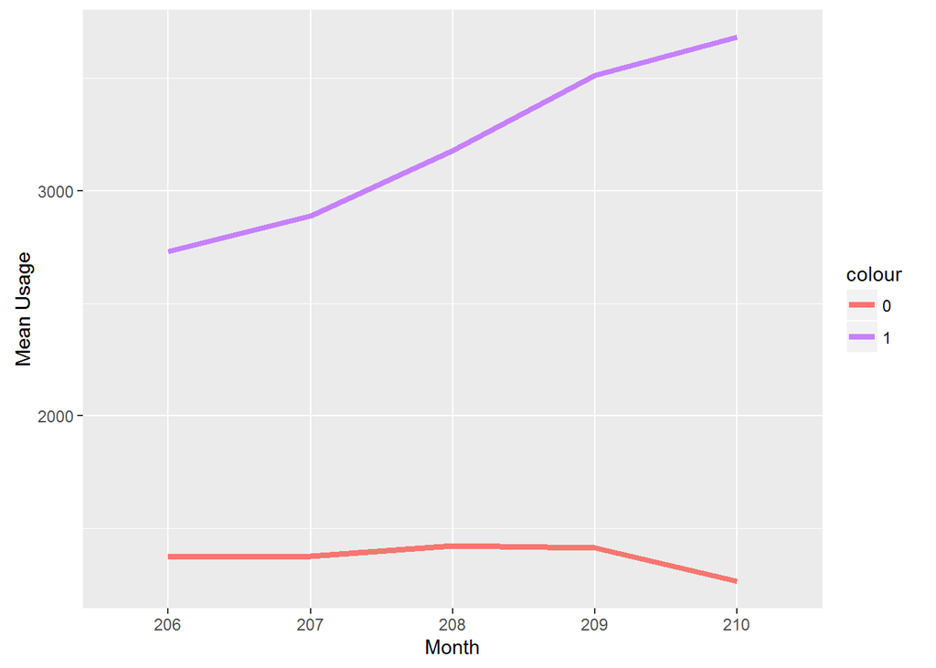

```r
ggplot(df, aes(monthly_names)) +
  geom_line(aes(y = avgs_monthly_usages_traget_1, colour='1'), size=1.5, group = 1) +
  geom_line(aes(y = avgs_monthly_usages_target_0, colour= '0'), size= 1.5, group = 1) +
  xlab("Month")+ylab("Mean Usage")  +
  scale_colour_manual(values=c("#F57670","#C680FC"))
```

The same as the mean for usage when the target is 1 However, we can notice that bump in the middle of the users where the target is 0.

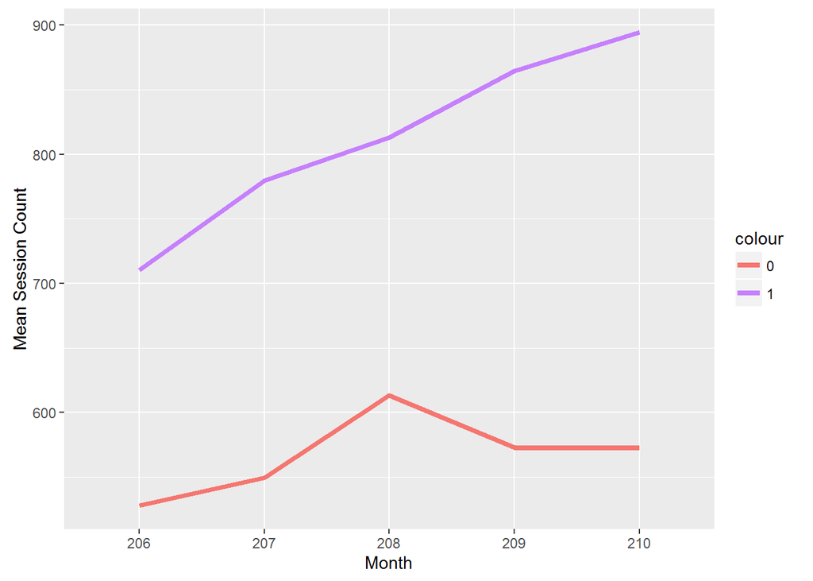

```r
ggplot(df, aes(monthly_names)) +
  geom_line(aes(y = avgs_monthly_sessions_count_traget_1, colour='1'), size=1.5, group = 1) +
  geom_line(aes(y = avgs_monthly_sessions_count_traget_0, colour= '0'), size= 1.5, group = 1) +
  xlab("Month")+ylab("Mean Session Count")  +
  scale_colour_manual(values=c("#F57670","#C680FC"))
```

```r
trainDf <- trainDf %>% rowwise() %>% mutate(diff1 = X207_USAGE - X206_USAGE, diff2 = X208_USAGE-X207_USAGE, diff3=X209_USAGE-X208_USAGE,diff4=X210_USAGE-X209_USAGE, always_increasing = (diff1 > 0 & diff2 > 0 & diff3 >0 & diff4 > 0))
```

# Offline Evaluation (Amir)

Due to the limited number of possible submissions per day on the kaggle competition, a method for offline evaluation of our obtained models was necessary. Two helper functions serve that purpose. The function `getEvaluation` extracts the required classification evaluation measures from a given confusion matrix.

```r
getEvaluation <- function(confMat) {
  tp <- confMat[1,1]
  fn <- confMat[1, 2]
  fp <- confMat[2, 1]
  tn <- confMat[2, 2]
  Accurary <- (tp + tn) / (tp + fn + fp + tn)
  Precision <- tp / (tp + fp)
  Recall <- tp / (tp + fn)
  F1 <- (2 * Precision * Recall) / (Precision + Recall)
  res <- cbind(Accurary,Precision,Recall,F1)
  return(res)
}
```

```r
evaluateModel <- function(model){
  tenFoldModel <- evaluate_Weka_classifier(model, numFolds = 5, seed = 123)
  tenFoldModel$confusionMatrix %>% getEvaluation %>% kable
}
```

# Progress tracking

In the following subsections we present a brief description of several approaches we tried in order to increase the prediction score. Each subsection denotes the person who carried out its approach, and related files to this approach (whether they are scripts, output files or workspace images) can be found in a folder inside the `scripts` folder with the following naming convention: `Number-Implementer-Score`.

## 1- Decision Tree classifier (Mimi)

By trying on on the Rweka’s J48 decision tree classifier on all features of the original train and test datasets, a kaggle score of `0.61` was obtained, so this is the approach used in the next three steps.

## 2- Decision tree classifier with value segment and rate plan (Mimi)

By continuing on approach in `1` and merging with contractRef dataframe and factoring the `RATE_PLAN` and `VALUE_SEGMENT` in the predictions, a less kaggle score of `0.59099` was obtained, so this approach was neglected.

## 3- Decision tree classifier with age (Amir)

By continuing on approach in `1` and merging with contractRef dataframe and factoring the `AGE` factor in the predictions, a less kaggle score of `0.59184` was obtained, so this approach was neglected.

## 4- Decisioon Tree with merging all `contract_ref.csv` columns (Amir)

By continuing on number `1` above (Decision Tree classifier), I merged with all columns from `contract_ref.csv`, and obtained a score of `0.57585`, which is a decrease from the original score, so this approach was neglected.

## 5- Naive Bayes classifier (Amir)

By trying on on the Naive Bayes classifier, a score of `0.56603` was obtained, which was less than that obtained from the Decision Tree classifier, so this approach was neglected.

## 6- Support Vector Machine classifier (Amir)

By trying on on the Support Vector Machine (SMO) classifier, a score of `0.50000` was obtained, which was less than that obtained from the Decision Tree classifier, so this approach was neglected.

## 7- Random Forest classifier (Amir)

By trying on on the Random Forest (RF) classifier, a score of `0.60032` was obtained, which was less than that obtained from the Decision tree classifier, so this approach was neglected.

## 8- Neural Network classifier (Mimi)

By trying on on the Neural Network (NN) classifier, a score of `0.63391` was obtained, which is the highest score from all classifiers, so this is the classifier that will be used from now on.

## 8.5 Local CV on J48, NB, SMO, MLP (Amir)

For each of the 4 classifiers: J48, NB, SMO & MLP, 5-fold cross validation was carried on my local machine using the above functions `getEvaluation` and `evaluateModel`. Due to the large running time, the code chunk used for evaluation is shown without running it, and a screenshot containing the results from a previous run is attached. (RF in particular had exceedingly large time that it was not included in the screenshot)

```r
model <- J48(TARGET~., data=trainDf)
evaluateModel(model)
model <- NB(TARGET~., data=trainDf)
evaluateModel(model)
model <- SMO(TARGET~., data=trainDf)
evaluateModel(model)
model <- MLP(TARGET~., data=trainDf)
evaluateModel(model)
rm(model)
```

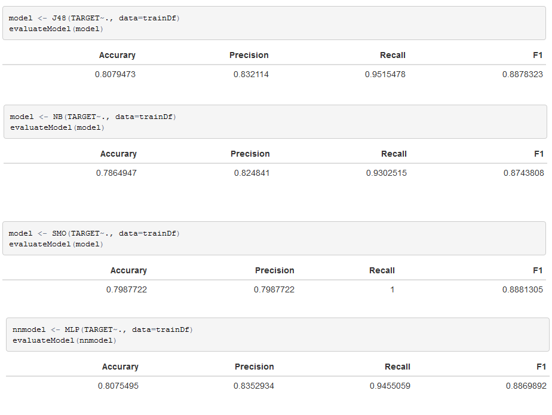

### Reasoning in the initial CV scores

It should be noted that the NN classifier which had the highest score on kaggle is the one with the highest precision in the 5-fold CV. Also, when studying the results of the SMO classifier, I was amused to find that the perfect recall score and the 0.79 precision are due to the fact that it recommended all target as `0`. It correctly classified all the 0-target observations as it classified all the observations as 0. Moreover, it scored a precision of 0.79 because this is the actual ratio of 0-target observations in the training set. From the misleading results of the SMO classifier, we deduce that the precision metric could be more valuable in our purpose, possibly due to the fact that most of the observations have a target of 0. However, some inspection of the classifier results in general are needed, as some high results due to overfitting can be misleading.

## 9- Neural Network with removing `SESSION_COUNT` columns (Amir)

By continuing on number `8` above (NN classifier), I removed all `SESSION_COUNT` from the prediction. The intuition behind this approach is that `USAGE` is the main concern here. However, a decreased score of `0.58118` was obtained, proving that session count indeed matters, and the approach here was neglected.

## 10- Neural Network with weighted monthly usages (Amir)

By continuing on number `8` above (NN classifier), an approach was tried to weigh all monthly usages. The intuition was that the last month would be the most important month, followed by the second to last month and so on. This was implemented by multiplying the usage columns in the last 4 months by values ranging from 2 to 5.

```r
trainDf <- trainDf %>% mutate(X207_USAGE=X207_USAGE*2, X208_USAGE=X208_USAGE*3,
                             X209_USAGE=X209_USAGE*4,X210_USAGE=X210_USAGE*5)
testDf <- testDf %>% mutate(X207_USAGE=X207_USAGE*2, X208_USAGE=X208_USAGE*3,
                             X209_USAGE=X209_USAGE*4,X210_USAGE=X210_USAGE*5)
```

A low score of `0.50587` was obtained as a result, so this approach was neglected. I suspect that the intuition itself could be sound but the way in which it was implemented was responsible for the decreased score.

## 11- Neural Network with only last month data (Amir)

By continuing on number `8` above (NN classifier), an approach was tried to only depend on the data from the last month, and neglect all the usage and session count columns from the first four months.

```r
trainKeeps <- c("CONTRACT_KEY","X210_SESSION_COUNT","X210_USAGE","TARGET")
trainDf <- trainDf[trainKeeps]
testKeeps <- c("CONTRACT_KEY","X210_SESSION_COUNT","X210_USAGE")
testDf <- testDf[testKeeps]
```

A score of `0.62686` was obtained which is surprisingly not much less than the original score of `0.63391`. But due to it being a lesser score, the approach was neglected.

## 12- Neural Network with removing `CONTRACT_KEY` from predictions (Amir)

I realized that the `CONTRACT_KEY` in both the train and test datasets factored as an integer in the predictions, which does not make sense at all. So, by removing it from predictions, an improved score of `0.65550` was obtained with the NN classifier. So, this approach is taken into account from now on. These are the features that are currently used to build the model:

```r
model <- MLP(TARGET~X206_SESSION_COUNT + X206_USAGE + X207_SESSION_COUNT + X207_USAGE + X208_SESSION_COUNT + X208_USAGE + X209_SESSION_COUNT + X209_USAGE + X210_SESSION_COUNT + X210_USAGE
                            , data=trainDf)
```

## 13- Feature engineering to integrate roaming data (Amir)

Buidling on the approach in `12`, I integrated with the roaming data from the `roaming_monthly.csv` file. For both the train and test datasets, 10 extra features were added as the roaming usage and roaming number of sessions for each of the 5 months. The values of these columns were extracted from the roamingDf as follows:

```r
trainDf <- trainDf
trainDf[,"R206_USAGE"] <- 0
trainDf[,"R206_SESSION_COUNT"] <- 0
trainDf[,"R207_USAGE"] <- 0
trainDf[,"R207_SESSION_COUNT"] <- 0
trainDf[,"R208_USAGE"] <- 0
trainDf[,"R208_SESSION_COUNT"] <- 0
trainDf[,"R209_USAGE"] <- 0
trainDf[,"R209_SESSION_COUNT"] <- 0
trainDf[,"R210_USAGE"] <- 0
trainDf[,"R210_SESSION_COUNT"] <- 0

testDf <- testDf
testDf[,"R206_USAGE"] <- 0
testDf[,"R206_SESSION_COUNT"] <- 0
testDf[,"R207_USAGE"] <- 0
testDf[,"R207_SESSION_COUNT"] <- 0
testDf[,"R208_USAGE"] <- 0
testDf[,"R208_SESSION_COUNT"] <- 0
testDf[,"R209_USAGE"] <- 0
testDf[,"R209_SESSION_COUNT"] <- 0
testDf[,"R210_USAGE"] <- 0
testDf[,"R210_SESSION_COUNT"] <- 0

for (k in unique(roamingDf$CONTRACT_KEY)) {
  orig <- roamingDf[roamingDf$CONTRACT_KEY==k,]
  if (trainDf[trainDf$CONTRACT_KEY==k,] %>% nrow > 0) {
    val <- orig[orig$CALL_MONTH_KEY == 206,]
    if (nrow(val) > 0) {
      trainDf[trainDf$CONTRACT_KEY==k,"R206_USAGE"] = val$USAGE
      trainDf[trainDf$CONTRACT_KEY==k,"R206_SESSION_COUNT"] = val$SESSION_COUNT
    }
    val <- orig[orig$CALL_MONTH_KEY == 207,]
    if (nrow(val) > 0) {
      trainDf[trainDf$CONTRACT_KEY==k,"R207_USAGE"] = val$USAGE
      trainDf[trainDf$CONTRACT_KEY==k,"R207_SESSION_COUNT"] = val$SESSION_COUNT
    }
    val <- orig[orig$CALL_MONTH_KEY == 208,]
    if (nrow(val) > 0) {
      trainDf[trainDf$CONTRACT_KEY==k,"R208_USAGE"] = val$USAGE
      trainDf[trainDf$CONTRACT_KEY==k,"R208_SESSION_COUNT"] = val$SESSION_COUNT
    }
    val <- val[val$CALL_MONTH_KEY == 209,]
    if (nrow(val) > 0) {
      trainDf[trainDf$CONTRACT_KEY==k,"R209_USAGE"] = val$USAGE
      trainDf[trainDf$CONTRACT_KEY==k,"R209_SESSION_COUNT"] = val$SESSION_COUNT
    }
    val <- orig[orig$CALL_MONTH_KEY == 210,]
    if (nrow(val) > 0) {
      trainDf[trainDf$CONTRACT_KEY==k,"R210_USAGE"] = val$USAGE
      trainDf[trainDf$CONTRACT_KEY==k,"R210_SESSION_COUNT"] = val$SESSION_COUNT
    }
  }
  else {
    val <- orig[orig$CALL_MONTH_KEY == 206,]
    if (nrow(val) > 0) {
      testDf[testDf$CONTRACT_KEY==k,"R206_USAGE"] = val$USAGE
      testDf[testDf$CONTRACT_KEY==k,"R206_SESSION_COUNT"] = val$SESSION_COUNT
    }
    val <- orig[orig$CALL_MONTH_KEY == 207,]
    if (nrow(val) > 0) {
      testDf[testDf$CONTRACT_KEY==k,"R207_USAGE"] = val$USAGE
      testDf[testDf$CONTRACT_KEY==k,"R207_SESSION_COUNT"] = val$SESSION_COUNT
    }
    val <- orig[orig$CALL_MONTH_KEY == 208,]
    if (nrow(val) > 0) {
      testDf[testDf$CONTRACT_KEY==k,"R208_USAGE"] = val$USAGE
      testDf[testDf$CONTRACT_KEY==k,"R208_SESSION_COUNT"] = val$SESSION_COUNT
    }
    val <- val[val$CALL_MONTH_KEY == 209,]
    if (nrow(val) > 0) {
      testDf[testDf$CONTRACT_KEY==k,"R209_USAGE"] = val$USAGE
      testDf[testDf$CONTRACT_KEY==k,"R209_SESSION_COUNT"] = val$SESSION_COUNT
    }
    val <- orig[orig$CALL_MONTH_KEY == 210,]
    if (nrow(val) > 0) {
      testDf[testDf$CONTRACT_KEY==k,"R210_USAGE"] = val$USAGE
      testDf[testDf$CONTRACT_KEY==k,"R210_SESSION_COUNT"] = val$SESSION_COUNT
    }
  }
}
```

By factoring the 10 roaming features into the prediction as well, an improved score of `0.67939` was reached. So, these features are taken into consideration from now on.

## 14- Adjustment to roaming data (Amir)

Buidling on the approach in `13`, I implemented a small adjustment by subtracting the newly added monthly roaming data from original total mothly data, so that the original usage and session count columns would now describe local data only.

```r
trainDf <- trainDf %>% mutate(X206_SESSION_COUNT = X206_SESSION_COUNT - R206_SESSION_COUNT,
                                      X206_USAGE = X206_USAGE - R206_USAGE,
                                      X207_SESSION_COUNT = X207_SESSION_COUNT - R207_SESSION_COUNT,
                                      X207_USAGE = X207_USAGE - R207_USAGE,
                                      X208_SESSION_COUNT = X208_SESSION_COUNT - R208_SESSION_COUNT,
                                      X208_USAGE = X208_USAGE - R208_USAGE,
                                      X209_SESSION_COUNT = X209_SESSION_COUNT - R209_SESSION_COUNT,
                                      X209_USAGE = X209_USAGE - R209_USAGE,
                                      X210_SESSION_COUNT = X210_SESSION_COUNT - R210_SESSION_COUNT,
                                      X210_USAGE = X210_USAGE - R210_USAGE)

testDf <- testDf %>% mutate(X206_SESSION_COUNT = X206_SESSION_COUNT - R206_SESSION_COUNT,
                                      X206_USAGE = X206_USAGE - R206_USAGE,
                                      X207_SESSION_COUNT = X207_SESSION_COUNT - R207_SESSION_COUNT,
                                      X207_USAGE = X207_USAGE - R207_USAGE,
                                      X208_SESSION_COUNT = X208_SESSION_COUNT - R208_SESSION_COUNT,
                                      X208_USAGE = X208_USAGE - R208_USAGE,
                                      X209_SESSION_COUNT = X209_SESSION_COUNT - R209_SESSION_COUNT,
                                      X209_USAGE = X209_USAGE - R209_USAGE,
                                      X210_SESSION_COUNT = X210_SESSION_COUNT - R210_SESSION_COUNT,
                                      X210_USAGE = X210_USAGE - R210_USAGE)
```

The score improved to `0.68188` which makes sense. So, this approach is implemented from now on.

## 15- Adding `RATE_PLAN` feature (Amir)

Building on `14`, I added the `RATE_PLAN` feature from `contract_ref` in the model prediction. Building this model took several hours on my local machine, which was expected due to the large number of levels for this feature (183 levels). However, this largely sabotaged the prediction process as a minimum score of `0.50000` resulted from this approach. This indicated that some feature engineering needs to be done on this feature and all features in `contract_ref` in general to obtain more useful parameters.

## 16- Adaboosting with NN as base classifier (Amir)

Buidling on `14`, instead of using NN base classifier, I used boosting with `AdaboostM1` and with NN as its base classifier. Surprisingly, I obtained a score of `0.67495` which is less than the one obtained with the base classifier only.

## 17- Analysing the `GENDER` from `contract_ref` and adding it to the predictions (Tony & Amir)

Let’s check all the possible values that exist:

```r
contractRefDf$GENDER %>% unique
```

```
## [1] Male        Female      Not Entered M           Unknown     F
## [7] m           f
## Levels: f F Female m M Male Not Entered Unknown
```

As we can see, we have 3 different values representing a “Female” gender (“f”, “F” and “Female”). Also for the “Male” gender we have 3 different values for it (“m”, “M” and “Male”). There are also 2 other values representing a gender not entered (or unknown), which reflects the same meaning (“Not Entered” and “Unknown”). We shall combine them into their corresponding 3 main categories (“Female”, “Male” and “Unknown”).

```r
contractRefDf$GENDER[contractRefDf$GENDER == "f"] <- "Female"
contractRefDf$GENDER[contractRefDf$GENDER == "F"] <- "Female"
contractRefDf$GENDER[contractRefDf$GENDER == "m"] <- "Male"
contractRefDf$GENDER[contractRefDf$GENDER == "M"] <- "Male"
contractRefDf$GENDER[contractRefDf$GENDER == "Not Entered"] <- "Unknown"
```

So adding the `GENDER` to the predicitions after the above modifications, we get a score of `0.66270` (less than the last state before adding the `GENDER` to the predictions).

## – Some insight into the data (Mimi)

```r
percentage_calculator <- function(target, threshold, colName){
    exp <- paste("(trainDf %>% filter(",colName,"< threshold & TARGET == target) %>% nrow() / trainDf %>% filter(",colName,"< threshold) %>% nrow()  ) * 100",sep='')
    eval(parse(text = exp))
}
range(trainDf$X210_USAGE)
```

```
## [1]      0 249308
```

The percentag of users who have X210_USAGE < 100MB to be target 0

```r
percentage_calculator(0,100,"X210_USAGE")
```

```
## [1] 97.6272
```

The percentag of users who have X210_USAGE < 500MB to be target 0

```r
percentage_calculator(0,500,"X210_USAGE")
```

```
## [1] 94.81254
```

The percentag of users who have X210_USAGE < 2000MB to be target 0

```r
percentage_calculator(0,2000,"X210_USAGE")
```

```
## [1] 87.44142
```

The number of users with target euqal to 1 become to overcome the users with target 0 when X210_USAGE execeds almost 4000 MB

```r
trainDf %>% filter(X210_USAGE > 4000 & TARGET == 1) %>% nrow
```

```
## [1] 4151
```

```r
trainDf %>% filter(X210_USAGE > 4000 & TARGET == 0) %>% nrow
```

```
## [1] 4186
```

## – Some insight into the data (Tony)

```r
trainDf <- trainDf %>% rowwise() %>% mutate(mean_usage_temp = mean(c(X206_USAGE,X207_USAGE,X208_USAGE,X209_USAGE,X210_USAGE)))
trainDf <- trainDf %>% rowwise() %>% mutate(mean_session_count_temp = mean(c(X206_SESSION_COUNT,X207_SESSION_COUNT,X208_SESSION_COUNT,X209_SESSION_COUNT,X210_SESSION_COUNT)))
trainDf <- trainDf %>% rowwise() %>% mutate(total_session_count_temp = X206_SESSION_COUNT+X207_SESSION_COUNT+X208_SESSION_COUNT+X209_SESSION_COUNT+X210_SESSION_COUNT)
```

The percentage of users whose mean data usage is < 100 MB to be target 0

```r
percentage_calculator(0,100,"mean_usage_temp")
```

```
## [1] 98.64896
```

The percentage of users whose mean data usage is < 500 MB to be target 0

```r
percentage_calculator(0,500,"mean_usage_temp")
```

```
## [1] 94.56911
```

The percentage of users whose mean data usage is < 1000 MB to be target 0

```r
percentage_calculator(0,1000,"mean_usage_temp")
```

```
## [1] 90.38777
```

The percentage of users whose mean session count is < 5 to be target 0

```r
percentage_calculator(0,5,"mean_session_count_temp")
```

```
## [1] 98.06763
```

The percentage of users whose mean session count is < 50 to be target 0

```r
percentage_calculator(0,50,"mean_session_count_temp")
```

```
## [1] 92.2673
```

The percentage of users whose mean session count is < 500 to be target 0

```r
percentage_calculator(0,500,"mean_session_count_temp")
```

```
## [1] 84.34121
```

The percentage of users whose total session count is < 50 to be target 0

```r
percentage_calculator(0,50,"total_session_count_temp")
```

```
## [1] 96.46762
```

The percentage of users whose total session count is < 500 to be target 0

```r
percentage_calculator(0,500,"total_session_count_temp")
```

```
## [1] 91.22414
```

The percentage of users whose total session count is < 1000 to be target 0

```r
percentage_calculator(0,1000,"total_session_count_temp")
```

```
## [1] 88.59143
```

## 18- Attempt to add features from slope and monthly distance (Mimi)

Building on 15, added 4 features representing differences between each two consecutive months, and one feature representing the average between the 4 differences (which represents an average slope). And a sixth feature representing average difference between last and first months. When factoring those 6 features in the prediction, a lesser score of 0.67884 was obtained.

```r
trainDf$slop1 <- apply(trainDf,1,slope1)
trainDf$slop2 <- apply(trainDf,1,slope2)
trainDf$slop3 <- apply(trainDf,1,slope3)
trainDf$slop4 <- apply(trainDf,1,slope4)
trainDf$slop1to5 <- apply(trainDf,1,slope1to5)
trainDf$avg_slop <- apply(trainDf,1,avg_slope)

testDf$slop1 <- apply(testDf,1,slope1)
testDf$slop2 <- apply(testDf,1,slope2)
testDf$slop3 <- apply(testDf,1,slope3)
testDf$slop4 <- apply(testDf,1,slope4)
testDf$slop1to5 <- apply(testDf,1,slope1to5)
testDf$avg_slop <- apply(testDf,1,avg2_slope)
```

## 22- Analysing and extracting new features from `RATE_PLAN` and adding it to the predictions - Trial 1 (Tony)

```r
contractRefDfTemp <- contractRefDf
```

As it was mentioned before, a large number of levels exist for such feature.

```r
contractRefDfTemp$RATE_PLAN %>% unique %>% length
```

```
## [1] 183
```

Now getting to know the different unique values for the `RATE_PLAN`:

```r
contractRefDfTemp$RATE_PLAN %>% unique
```

```
##   [1] Vodafone Easy 50               Flex 40
##   [3] Business USB 250 unlimited     Red 300
##   [5] Business Flex 35               Red 150
##   [7] 2013 Business El Asly 100      2013 Business El Asly 30
##   [9] Flex 40 Hybrid CL 50           POS Rate Plan
##  [11] Enterprise Shared Data Bundle  Business USB 110 unlimited
##  [13] Ostooly                        Business Red 150
##  [15] Arabeety                       Red 250 Control
##  [17] 2013 Business El Asly 50       Business Flex 30
##  [19] 2014 ElAsly Plus 35            Business USB 60 unlimited
##  [21] Business Flex 75               Business Red 250
##  [23] 2012 Bouquet 100 Revamp        Business USB 25 Control
##  [25] 2012 Bouquet Ctrl 25           2012 Bouquet 25 Revamp
##  [27] Red 350 Control                Unified USB 3.5 GB
##  [29] VF Data Solution 250           Vodafone Easy 150
```

[output cut: 78 more lines]

We can see that there are some similarities within some of those different values that would reflect the same info/value. For example, *2013 Business El Asly 30* and *2014 Business El Asly 30* are two different `RATE_PLAN` values that mainly reflect the same rate plan but for different years. Hence, one of the things to be done, is to discard the year value from the `RATE_PLAN`.

```r
contractRefDfTemp$RATE_PLAN <- gsub("[2][0][0-9][0-9] ", "", contractRefDfTemp$RATE_PLAN)
contractRefDfTemp$RATE_PLAN %>% unique %>% length
```

```
## [1] 174
```

The `RATE_PLAN` levels dropped to 174, which is not a remarkable difference.

Also other numerical values were also excluded like the amount of GBs and the rate plan monetary value. The rate plans including the descriptive amount of data in GBs are very few out of the total unique values we have:

```r
contractRefDfTemp$RATE_PLAN[grepl(" [0-9]+(\\.[0-9]*)* GB", contractRefDfTemp$RATE_PLAN)] %>% unique %>% length
```

```
## [1] 7
```

Also the number of customers subscribed to those rate plans are also a small percentage (6.440326 %):

```r
contractRefDfTemp$CONTRACT_KEY[grepl(" [0-9]+(\\.[0-9]*)* GB", contractRefDfTemp$RATE_PLAN)] %>% length
```

```
## [1] 6939
```

```r
contractRefDfTemp$CONTRACT_KEY[grepl(" [0-9]+(\\.[0-9]*)* GB", contractRefDfTemp$RATE_PLAN)] %>% length / contractRefDfTemp %>% nrow * 100
```

```
## [1] 6.440326
```

So let’s just exclude the above mentioned numerical values and only consider the remaining part of the `RATE_PLAN` and see if it would positively affect the results.

```r
contractRefDfTemp$RATE_PLAN <- gsub(" [0-9]+(\\.[0-9]*)* GB", "", contractRefDfTemp$RATE_PLAN)
contractRefDfTemp$RATE_PLAN <- gsub(" [0-9]+", "", contractRefDfTemp$RATE_PLAN)
contractRefDfTemp$RATE_PLAN <- as.factor(contractRefDfTemp$RATE_PLAN)
```

Let’s see the different levels in the `RATE_PLAN` how they look now:

```r
contractRefDfTemp$RATE_PLAN %>% unique
```

```
##  [1] Vodafone Easy                 Flex
##  [3] Business USB unlimited        Red
##  [5] Business Flex                 Business El Asly
##  [7] Flex Hybrid CL                POS Rate Plan
##  [9] Enterprise Shared Data Bundle Ostooly
## [11] Business Red                  Arabeety
## [13] Red Control                   ElAsly Plus
## [15] Bouquet Revamp                Business USB Control
## [17] Bouquet Ctrl                  Unified USB
## [19] VF Data Solution              VPN Partners
## [21] Flex CL                       Employee VPN
## [23] Ostooly Plus                  Business Use VPN
## [25] Flex Business                 Bouquet Ctrl Revamp
## [27] Bouquet                       RED Traveler
## [29] Employee VPN with Desk phone  Upper Egypt Tariff CTRL
```

[output cut: 28 more lines]

Let’s check now the number of `RATE_PLAN` levels:

```r
contractRefDfTemp$RATE_PLAN %>% unique %>% length
```

```
## [1] 83
```

As we can see, the impact was remarkable; as the `RATE_PLAN` levels dropped from 183 to 83 only. However, adding it to the predictions, the score has decreased to `0.58943`. Hence, this approach has to be excluded for the moment until further feature engineering concerning the `RATE_PLAN` are applied.

## 23- Analysing the `HANDSET_NAME` from `contractRefDf` and extracting some features from it to include in the predictions (Tony)

First, let’s see the different possible values for the `HANDSET_NAME`.

```r
contractRefDf$HANDSET_NAME %>% unique %>% length
```

```
## [1] 2058
```

Let’s see what some of those diffrent values are:

```r
contractRefDf$HANDSET_NAME %>% unique %>% head
```

```
## [1] Sony Xperia C3 dual   BlackBerry Curve 9320 Vodafone R207
## [4] Nokia X2-02           Apple iPhone 6        Lenovo Vibe P1a
## 2058 Levels:  Ace Group G005 Ace Group YXTEL G929 ... ZTS International X2,C1
```

Very huge possible values exist for the `HANDSET_NAME`. Let’s extract a handset category by merging different `HANDSET_NAME` values into categories that correspond to the manufacturer so that they relatively reflect a common behavior/usage of the handset device. So let’s have a new column (attribute) to store this new feature `HANSET_CAT`, where the first occuring keyword in the `HANSET_NAME` is corresponding to such value/feature.

```r
contractRefDf <- contractRefDf %>% mutate(HANDSET_CAT = gsub(" (.)*$", "", HANDSET_NAME))
contractRefDf$HANDSET_CAT <- as.factor(contractRefDf$HANDSET_CAT)
```

The different possible values of this new attribute/feature has a remarkably fewer values from the `HANDSET_NAME`.

```r
contractRefDf$HANDSET_CAT %>% unique %>% length
```

```
## [1] 230
```

Adding the `HANDSET_CAT` to the predicitions, we get a minimum score of `0.50000`. Hence, more feature engineering has to be done on this feature to obtain positive impact from it.

## 24- Assuming that the `iPhone` users are the most likely to exceed their average usage (Tony)

Assuming that the different devices used have different data usage/consumption according to the firmware and other factors that may, added up to the personal customer’s usage, reflect an intention to exceed the usage limit. So let’s extract a new parameter differentiating the `iPhone` users from the others:

```r
contractRefDf <- contractRefDf %>% mutate(iPhone = ifelse(grepl("iPhone", HANDSET_NAME), 1, 0))
```

Adding this feature to the predictions yields a score of `0.67081`, which is not an improvement. Hence, taking the used device into account for the predictions won’t be considered for the moment.

## 25- Feature engineering to integrate daily aggregate data (Mimi)

Building on 14 which is the last score increasing approach, we integrate the daily data.For each user, we extract (from the daily aggregate df) for each day of the week the local and roaming usage and session count. But we don’t have the daily data for all the users in the 5th month. So, we divide the last month data equally among the seven week days. This approach improved the score to `0.69884` so the extracted features here are added to our feature set afterwards.

```r
monthly_usage_columns <- c('X206_USAGE','X207_USAGE','X208_USAGE','X209_USAGE','X210_USAGE')
  weekdays <- c('Saturday','Sunday','Monday','Tuesday','Wednesday','Thursday','Friday')
  colnames(dailyAggDf)[2] <- "DATE_KEY"
  a <- merge(dailyAggDf, calendarRefDf, BY = "DATE_KEY")
  a$TOTAL_CONSUMPTION <- a$TOTAL_CONSUMPTION/1024/1024

    for(name in weekdays){
      # Local Data
      col_name_usage <- paste('local_',name,'_usage',sep='')
      col_name_sessions_count <- paste('local_',name,'_sessions_count',sep='')
      filtered_data <- a %>% filter(ROAMING_FLAG == "LOCAL" & DAY_NAME == name)

      exp <- paste("filtered_data %>% group_by(CONTRACT_KEY) %>%
        summarise(", col_name_usage, "= sum(TOTAL_CONSUMPTION),",col_name_sessions_count,"=sum(NO_OF_SESSIONS) )", sep = "")
      local <- eval(parse(text = exp))
      trainDf <- merge(trainDf,local, BY = "CONTRACT_KEY",all.x = T)
      testDf <- merge(testDf,local, BY = "CONTRACT_KEY",all.x = T)

      ##Remove Na's
      #local usage
      exp <- paste("trainDf <- trainDf %>% mutate(",col_name_usage,"= ifelse(is.na(",col_name_usage,"),X210_USAGE/7,",col_name_usage,"))", sep= "")
      eval(parse(text = exp))

      #local sessions count
      exp <- paste("trainDf <- trainDf %>% mutate(",col_name_sessions_count,"= ifelse(is.na(",col_name_sessions_count,"),X210_SESSION_COUNT/7,",col_name_sessions_count,"))", sep= "")
      eval(parse(text = exp))

      ##Remove Na's
      #testing
      exp <- paste("testDf <- testDf %>% mutate(",col_name_usage,"= ifelse(is.na(",col_name_usage,"),X210_USAGE/7,",col_name_usage,"))", sep= "")
      eval(parse(text = exp))

      exp <- paste("testDf <- testDf %>% mutate(",col_name_sessions_count,"= ifelse(is.na(",col_name_sessions_count,"),X210_SESSION_COUNT/7,",col_name_sessions_count,"))", sep= "")
      eval(parse(text = exp))

      #Roaming Data
      col_name_usage <- paste('roaming_',name,'_usage',sep='')
      col_name_sessions_count <- paste('roaming_',name,'_sessions_count',sep='')

      filtered_data <- a %>% filter(ROAMING_FLAG == "ROAMING" & DAY_NAME == name)
      exp <- paste("filtered_data %>% group_by(CONTRACT_KEY) %>%
        summarise(", col_name_usage, "= sum(TOTAL_CONSUMPTION),",col_name_sessions_count,"=sum(NO_OF_SESSIONS) )", sep = "")
      roaming <- eval(parse(text = exp))
      trainDf <- merge(trainDf,roaming, BY = "CONTRACT_KEY",all.x = T)
      testDf <- merge(testDf,roaming, BY = "CONTRACT_KEY",all.x = T)

      ##Remove Na's
      #roamiming usage
      exp <- paste("trainDf <- trainDf %>% mutate(",col_name_usage,"= ifelse(is.na(",col_name_usage,"),R210_USAGE/7,",col_name_usage,"))", sep= "")
      eval(parse(text = exp))

      #roamiming sessions count
      exp <- paste("trainDf <- trainDf %>% mutate(",col_name_sessions_count,"= ifelse(is.na(",col_name_sessions_count,"),R210_SESSION_COUNT/7,",col_name_sessions_count,"))", sep= "")
      eval(parse(text = exp))

      ##Remove Na's
      #roamiming usage
      exp <- paste("testDf <- testDf %>% mutate(",col_name_usage,"= ifelse(is.na(",col_name_usage,"),R210_USAGE/7,",col_name_usage,"))", sep= "")
      eval(parse(text = exp))

      #local sessions count
      exp <- paste("testDf <- testDf %>% mutate(",col_name_sessions_count,"= ifelse(is.na(",col_name_sessions_count,"),R210_SESSION_COUNT/7,",col_name_sessions_count,"))", sep= "")
      eval(parse(text = exp))
  }
```

## 26- Add weekday and weekend data (Mimi)

Buidling on the previous approach, we build four more features, which is the usage and session count of the weekdays and weekends. This approach improved the score to `0.70333` so this approach is taken into account.

```r
  ## Train
  trainDf <- trainDf %>% rowwise() %>% mutate(
    weekday_usage = sum(c(local_Sunday_usage,roaming_Sunday_usage,local_Monday_usage,roaming_Monday_usage,local_Tuesday_usage,roaming_Tuesday_usage,local_Wednesday_usage,roaming_Wednesday_usage,local_Thursday_usage,roaming_Thursday_usage))
    ,
    weekday_sessions_count = sum(c(local_Sunday_sessions_count,roaming_Sunday_sessions_count,local_Monday_sessions_count,roaming_Monday_sessions_count,local_Tuesday_sessions_count,roaming_Tuesday_sessions_count,local_Wednesday_sessions_count,roaming_Wednesday_sessions_count,local_Thursday_sessions_count,roaming_Thursday_sessions_count))
    ,
    weekend_usage = sum(c(local_Friday_usage,roaming_Friday_usage,local_Saturday_usage,roaming_Saturday_usage))
    ,
    weekend_sessions_count = sum(c(local_Friday_sessions_count,roaming_Friday_sessions_count,local_Saturday_sessions_count,roaming_Saturday_sessions_count))
   )

  ## Test
  testDf <- testDf %>% rowwise() %>% mutate(
    weekday_usage = sum(c(local_Sunday_usage,roaming_Sunday_usage,local_Monday_usage,roaming_Monday_usage,local_Tuesday_usage,roaming_Tuesday_usage,local_Wednesday_usage,roaming_Wednesday_usage,local_Thursday_usage,roaming_Thursday_usage))
    ,
    weekday_sessions_count = sum(c(local_Sunday_sessions_count,roaming_Sunday_sessions_count,local_Monday_sessions_count,roaming_Monday_sessions_count,local_Tuesday_sessions_count,roaming_Tuesday_sessions_count,local_Wednesday_sessions_count,roaming_Wednesday_sessions_count,local_Thursday_sessions_count,roaming_Thursday_sessions_count))
    ,
    weekend_usage = sum(c(local_Friday_usage,roaming_Friday_usage,local_Saturday_usage,roaming_Saturday_usage))
    ,
    weekend_sessions_count = sum(c(local_Friday_sessions_count,roaming_Friday_sessions_count,local_Saturday_sessions_count,roaming_Saturday_sessions_count))
   )
```

## 27- Adding features from aggregate functions (Mimi)

Continuing on 26, I added features representing mean and standard deviation and median between the monthly usage and session count columns, but it scored slightly less with 0.70053, so this approach is neglected.

```r
trainDf <- trainDf %>% rowwise() %>% mutate(
    mean_usage = mean(c(X206_USAGE,X207_USAGE,X208_USAGE,X209_USAGE,X210_USAGE)),

    sd_usage =sd(c(X206_USAGE,X207_USAGE,X208_USAGE,X209_USAGE,X210_USAGE)),

    median_usage = median(c(X206_USAGE,X207_USAGE,X208_USAGE,X209_USAGE,X210_USAGE) ),

    mean_sessions_count=mean(c(X206_SESSION_COUNT,X207_SESSION_COUNT,X208_SESSION_COUNT,X209_SESSION_COUNT,X210_SESSION_COUNT)),

    median_sessions_count=median(c(X206_SESSION_COUNT,X207_SESSION_COUNT,
      X208_SESSION_COUNT,X209_SESSION_COUNT,X210_SESSION_COUNT)),

    sd_sessions_count=sd(c(X206_SESSION_COUNT,X207_SESSION_COUNT,X208_SESSION_COUNT,X209_SESSION_COUNT,X210_SESSION_COUNT))
    )

  testDf <- testDf %>% rowwise() %>% mutate(
    mean_usage = mean(c(X206_USAGE,X207_USAGE,X208_USAGE,X209_USAGE,X210_USAGE)),

    sd_usage =sd(c(X206_USAGE,X207_USAGE,X208_USAGE,X209_USAGE,X210_USAGE)),

    median_usage = median(c(X206_USAGE,X207_USAGE,X208_USAGE,X209_USAGE,X210_USAGE) ),

    mean_sessions_count=mean(c(X206_SESSION_COUNT,X207_SESSION_COUNT,X208_SESSION_COUNT,X209_SESSION_COUNT,X210_SESSION_COUNT)),

    median_sessions_count=median(c(X206_SESSION_COUNT,X207_SESSION_COUNT,
      X208_SESSION_COUNT,X209_SESSION_COUNT,X210_SESSION_COUNT)),

    sd_sessions_count=sd(c(X206_SESSION_COUNT,X207_SESSION_COUNT,X208_SESSION_COUNT,X209_SESSION_COUNT,X210_SESSION_COUNT))
    )
```

## 28- Weighting missing days (Amir)

In approaches 25 & 26, the missing daily data was calculated by dividing the fifth monthly data among the seven days of the week. A more intuitive approach is followed here by looking at the available montly data distribution among the week days, and inferring the missing daily data to have the same distribution among the week days.So, the code in 25 is modified to be:

```r
allDaysTotal <- sum(a$TOTAL_CONSUMPTION)
dailyWeights <- a %>% group_by(DAY_NAME) %>% summarize(dayConsumption=sum(TOTAL_CONSUMPTION) / allDaysTotal)

for(name in weekdays){
  #daily weight
  weight <- dailyWeights[dailyWeights$DAY_NAME==name,c("dayConsumption")]
  weight <- weight[[1]]

  # Local Data
  col_name_usage <- paste('local_',name,'_usage',sep='')
  col_name_sessions_count <- paste('local_',name,'_sessions_count',sep='')
  filtered_data <- a %>% filter(ROAMING_FLAG == "LOCAL" & DAY_NAME == name)

  exp <- paste("filtered_data %>% group_by(CONTRACT_KEY) %>%
               summarise(", col_name_usage, "= sum(TOTAL_CONSUMPTION),",col_name_sessions_count,"=sum(NO_OF_SESSIONS) )", sep = "")
  local <- eval(parse(text = exp))
  trainDf <- merge(trainDf,local, BY = "CONTRACT_KEY",all.x = T)
  testDf <- merge(testDf,local, BY = "CONTRACT_KEY",all.x = T)

  ##Remove Na's
  #local usage
  exp <- paste("trainDf <- trainDf %>% mutate(",col_name_usage,"= ifelse(is.na(",col_name_usage,"),X210_USAGE * weight,",col_name_usage,"))", sep= "")
  eval(parse(text = exp))

  #local sessions count
  exp <- paste("trainDf <- trainDf %>% mutate(",col_name_sessions_count,"= ifelse(is.na(",col_name_sessions_count,"),X210_SESSION_COUNT * weight,",col_name_sessions_count,"))", sep= "")
  eval(parse(text = exp))

  ##Remove Na's
  #testing
  exp <- paste("testDf <- testDf %>% mutate(",col_name_usage,"= ifelse(is.na(",col_name_usage,"),X210_USAGE * weight,",col_name_usage,"))", sep= "")
  eval(parse(text = exp))

  exp <- paste("testDf <- testDf %>% mutate(",col_name_sessions_count,"= ifelse(is.na(",col_name_sessions_count,"),X210_SESSION_COUNT * weight,",col_name_sessions_count,"))", sep= "")
  eval(parse(text = exp))

  #Roaming Data
  col_name_usage <- paste('roaming_',name,'_usage',sep='')
  col_name_sessions_count <- paste('roaming_',name,'_sessions_count',sep='')

  filtered_data <- a %>% filter(ROAMING_FLAG == "ROAMING" & DAY_NAME == name)
  exp <- paste("filtered_data %>% group_by(CONTRACT_KEY) %>%
               summarise(", col_name_usage, "= sum(TOTAL_CONSUMPTION),",col_name_sessions_count,"=sum(NO_OF_SESSIONS) )", sep = "")
  roaming <- eval(parse(text = exp))
  trainDf <- merge(trainDf,roaming, BY = "CONTRACT_KEY",all.x = T)
  testDf <- merge(testDf,roaming, BY = "CONTRACT_KEY",all.x = T)

  ##Remove Na's
  #roamiming usage
  exp <- paste("trainDf <- trainDf %>% mutate(",col_name_usage,"= ifelse(is.na(",col_name_usage,"),R210_USAGE * weight,",col_name_usage,"))", sep= "")
  eval(parse(text = exp))

  #roamiming sessions count
  exp <- paste("trainDf <- trainDf %>% mutate(",col_name_sessions_count,"= ifelse(is.na(",col_name_sessions_count,"),R210_SESSION_COUNT * weight,",col_name_sessions_count,"))", sep= "")
  eval(parse(text = exp))


  ##Remove Na's
  #roamiming usage
  exp <- paste("testDf <- testDf %>% mutate(",col_name_usage,"= ifelse(is.na(",col_name_usage,"),R210_USAGE * weight,",col_name_usage,"))", sep= "")
  eval(parse(text = exp))

  #local sessions count
  exp <- paste("testDf <- testDf %>% mutate(",col_name_sessions_count,"= ifelse(is.na(",col_name_sessions_count,"),R210_SESSION_COUNT * weight,",col_name_sessions_count,"))", sep= "")
  eval(parse(text = exp))
}
```

However, this approach scored `0.69831` which is less than the original even distribution among the 7 days, so the approach here is neglected.

## 29- Add average usage slope (Amir)

Building on 26 (the last score successful approach), we add one more feature representing the average usage slope amomg the 5 months. But this approach produced a decreased score of `0.69886` and was discarded.

```r
trainDf <- trainDf %>% rowwise() %>% mutate(diff1 = X207_USAGE - X206_USAGE, diff2 = X208_USAGE-X207_USAGE, diff3=X209_USAGE-X208_USAGE,diff4=X210_USAGE-X209_USAGE, avgDif = (diff1 + diff2 + diff3 + diff4) / 4)
testDf <- testDf %>% rowwise() %>% mutate(diff1 = X207_USAGE - X206_USAGE, diff2 = X208_USAGE-X207_USAGE, diff3=X209_USAGE-X208_USAGE,diff4=X210_USAGE-X209_USAGE, avgDif = (diff1 + diff2 + diff3 + diff4) / 4)
```

## 30- Training smaller model with no redundant features (Amir)

Building on all the features in the last successful approach, a feature selection was carried on them. The intuition behind it was as follows: In the last feature set, there was the data for the 5th month along with data for each of the seven days in the 5th month along with weekend and weekday data in the 5th month. So, the idea here was to remove any seemingly redundant representations referring to the same thing in different ways. The features with respect to the 5th month and each day of week was removed, keeping only weekday and weekend features, and dividing them to local and roaming data.

```r
myModel <- MLP(
  TARGET ~ X206_SESSION_COUNT + X206_USAGE +
    X207_SESSION_COUNT + X207_USAGE +
    X208_SESSION_COUNT + X208_USAGE +
    X209_SESSION_COUNT + X209_USAGE +
    weekday_local_session_count + weekday_local_usage +
    weekend_local_session_count + weekend_local_usage +
    R206_SESSION_COUNT + R206_USAGE +
    R207_SESSION_COUNT + R207_USAGE +
    R208_SESSION_COUNT + R208_USAGE +
    R209_SESSION_COUNT + R209_USAGE +
    weekday_roaming_usage + + weekday_roaming_session_count +
    weekend_roaming_usage + + weekend_roaming_session_count
  , data = trainDf
)
```

However, a less score of `0.68192` was obtained, and the removed features are added again.

## 31- Adding a feature that reflects an increasing level of usage in the 5th month (Tony)

A new parameter was added depending on exceeding the average (mean) usage of the 4 months in the 5th one.

```r
trainDf <- trainDf %>% mutate(x = ifelse(mean(c(X206_USAGE, X207_USAGE, X208_USAGE, X209_USAGE)) < X210_USAGE, 1, 0))
testDf <- testDf %>% mutate(x = ifelse(mean(c(X206_USAGE, X207_USAGE, X208_USAGE, X209_USAGE)) < X210_USAGE, 1, 0))
```

Adding this new parameter to the predictions yields a score of `0.66639`, which is not an improvement, so this approach is neglected.

## Analysing the `VALUE_SEGMENT` from `contract_ref` (Tony)

Let’s check the unique values for the value segment:

```r
contractRefDf$VALUE_SEGMENT %>% unique
```

```
## [1] High     Med-High Med-Low  Premium  Core     N/A      Platinum <NA>
## Levels: Core High Med-High Med-Low N/A Platinum Premium
```

As we can see, we have some NAs in addition to “N/A” values. So let’s merge them together.

```r
contractRefDf$VALUE_SEGMENT[is.na(contractRefDf$VALUE_SEGMENT)] <- "N/A"
```

Let’s check the distribution of the different values of the `VALUE_SEGMENT` among the customers in a descending order

```r
vs_frequencies <- contractRefDf %>% filter(VALUE_SEGMENT != "N/A") %>% group_by(VALUE_SEGMENT) %>% summarise(VS_frequency = length(CONTRACT_KEY)) %>% arrange(desc(VS_frequency))
vs_frequencies
```

```
## Source: local data frame [6 x 2]
##
##   VALUE_SEGMENT VS_frequency
##          (fctr)        (int)
## 1          Core        48031
## 2          High        21666
## 3       Med-Low        12992
## 4      Med-High        12577
## 5       Premium         4157
## 6      Platinum          145
```

Let’s plot the result showing the frequencies where the X-Axis is for the `VALUE_SEGMENT` and the Y-Axis is for the corresponding frequency `VS_frequency`:

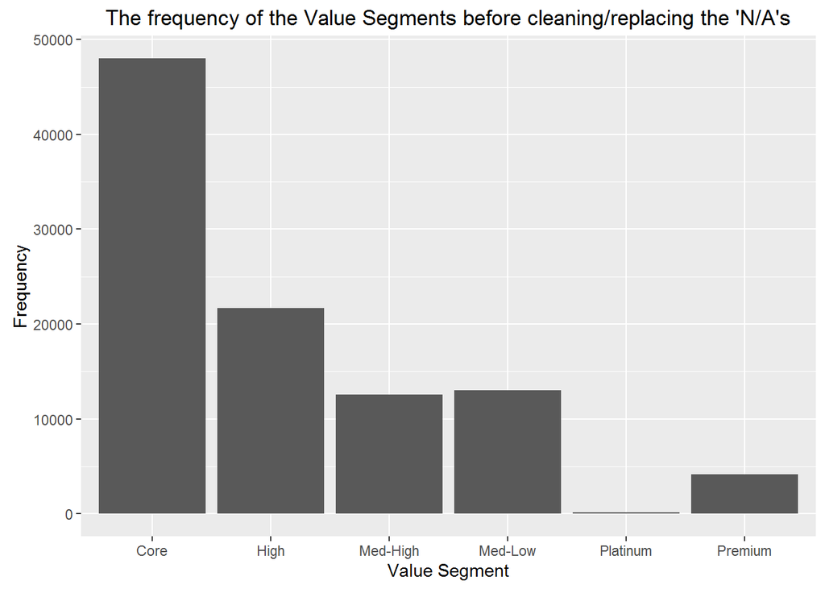

```r
vs_frequencies %>% ggplot(aes(x = VALUE_SEGMENT, y = VS_frequency)) + geom_bar(stat='identity') +
labs(title = "The frequency of the Value Segments before cleaning/replacing the 'N/A's", x = "Value Segment", y = "Frequency")
```

As we can see, almost half of the customers have a `VALUE_SEGMENT` of `Core`. It can be assumed that this is the default value untill some upgrade happens to classify the customer in a different higher category.

```r
contractRefDf %>% filter(VALUE_SEGMENT == "N/A") %>% nrow
```

```
## [1] 8175
```

One of the problems we have here is that a considerable number of records have “N/A” values for the `VALUE_SEGMENT` (8175).

### Let’s see if there’s a relation between the `VALUE_SEGMENT` and the `RATE_PLAN` or not:

```r
contractRefDf %>% group_by(RATE_PLAN) %>% summarise(RT_frequency = length(CONTRACT_KEY)) %>% arrange(desc(RT_frequency))
```

```
## Source: local data frame [183 x 2]
##
##                        RATE_PLAN RT_frequency
##                           (fctr)        (int)
## 1  Enterprise Shared Data Bundle        14155
## 2       2013 Business El Asly 30         8696
## 3               Business Flex 35         8046
## 4            2014 ElAsly Plus 35         7039
## 5                        Red 150         5456
## 6             2014 Flex 40 CL 50         3583
## 7                Red 150 Control         3507
## 8               Business Flex 30         3496
## 9       2013 Business El Asly 50         3170
## 10              Business Flex 50         2433
## ..                           ...          ...
```

The most frequent `RATE_PLAN` is the `Enterprise Shared Data Bundle`. Let’s check its relation with the `VALUE_SEGMENT`:

#### Enterprise Shared Data Bundle

```r
vs_frequencies <- contractRefDf %>% filter(RATE_PLAN == "Enterprise Shared Data Bundle", VALUE_SEGMENT != "N/A") %>% group_by(VALUE_SEGMENT) %>% summarise(VS_frequency = length(CONTRACT_KEY)) %>% arrange(desc(VS_frequency))
vs_frequencies
```

```
## Source: local data frame [5 x 2]
##
##   VALUE_SEGMENT VS_frequency
##          (fctr)        (int)
## 1          Core        13721
## 2      Med-High           38
## 3       Med-Low           29
## 4          High            7
## 5       Premium            4
```

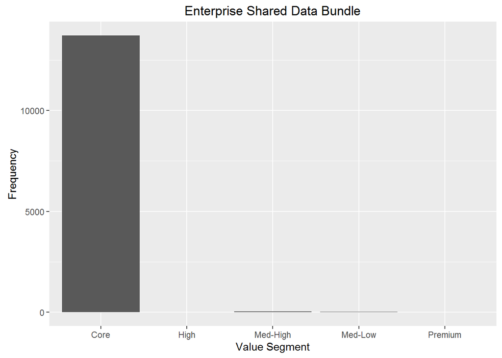

```r
vs_frequencies %>% ggplot(aes(x = VALUE_SEGMENT, y = VS_frequency)) + geom_bar(stat='identity') +
labs(title = "Enterprise Shared Data Bundle", x = "Value Segment", y = "Frequency")
```

The next most dominant rate plans are the following: `2013 Business El Asly 30`, `Business Flex 35`, `2014 ElAsly Plus 35`, and `Red 150`. So let’s check their corresponding relations with the `VALUE_SEGMENT`.

#### 2013 Business El Asly 30

```r
vs_frequencies <- contractRefDf %>% filter(RATE_PLAN == "2013 Business El Asly 30", VALUE_SEGMENT != "N/A") %>% group_by(VALUE_SEGMENT) %>% summarise(VS_frequency = length(CONTRACT_KEY)) %>% arrange(desc(VS_frequency))
vs_frequencies
```

```
## Source: local data frame [6 x 2]
##
##   VALUE_SEGMENT VS_frequency
##          (fctr)        (int)
## 1          Core         7114
## 2       Med-Low          955
## 3      Med-High          425
## 4          High          132
## 5       Premium            9
## 6      Platinum            1
```

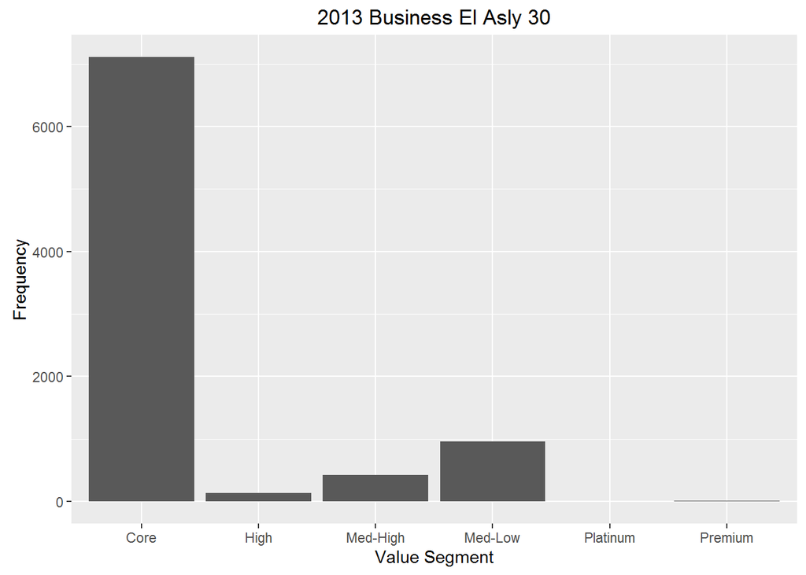

```r
vs_frequencies %>% ggplot(aes(x = VALUE_SEGMENT, y = VS_frequency)) + geom_bar(stat='identity') +
labs(title = "2013 Business El Asly 30", x = "Value Segment", y = "Frequency")
```

#### Business Flex 35

```r
vs_frequencies <- contractRefDf %>% filter(RATE_PLAN == "Business Flex 35", VALUE_SEGMENT != "N/A") %>% group_by(VALUE_SEGMENT) %>% summarise(VS_frequency = length(CONTRACT_KEY)) %>% arrange(desc(VS_frequency))
vs_frequencies
```

```
## Source: local data frame [6 x 2]
##
##   VALUE_SEGMENT VS_frequency
##          (fctr)        (int)
## 1          Core         7065
## 2       Med-Low          516
## 3      Med-High          197
## 4          High           83
## 5       Premium            3
## 6      Platinum            2
```

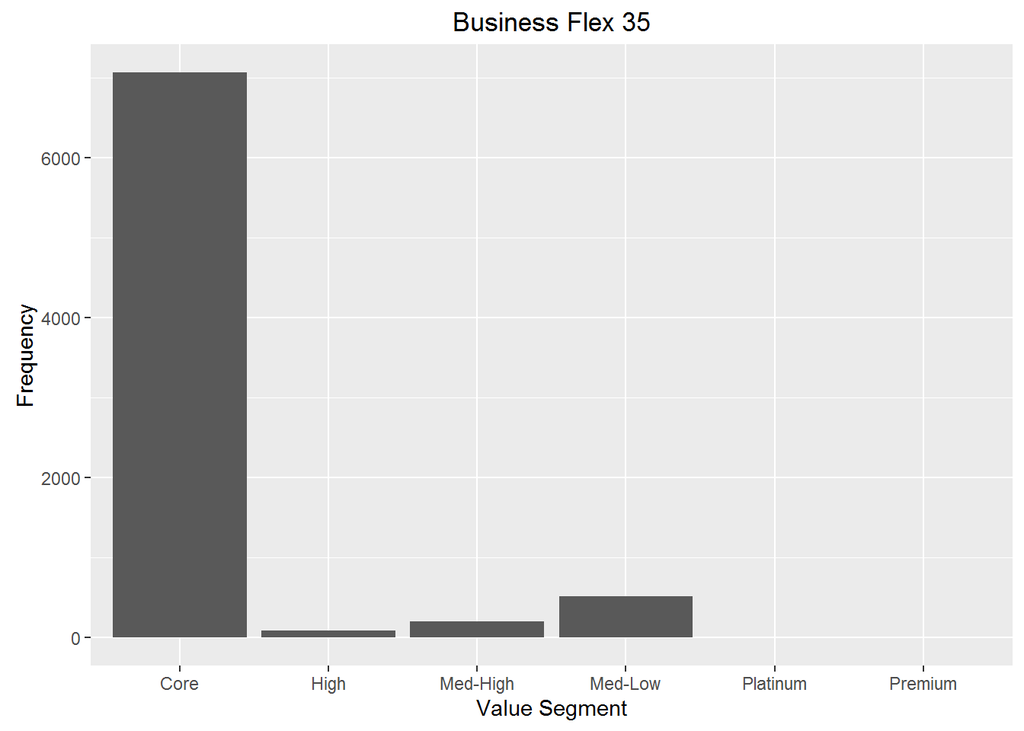

```r
vs_frequencies %>% ggplot(aes(x = VALUE_SEGMENT, y = VS_frequency)) + geom_bar(stat='identity') +
labs(title = "Business Flex 35", x = "Value Segment", y = "Frequency")
```

#### 2014 ElAsly Plus 35

```r
vs_frequencies <- contractRefDf %>% filter(RATE_PLAN == "2014 ElAsly Plus 35", VALUE_SEGMENT != "N/A") %>% group_by(VALUE_SEGMENT) %>% summarise(VS_frequency = length(CONTRACT_KEY)) %>% arrange(desc(VS_frequency))
vs_frequencies
```

```
## Source: local data frame [6 x 2]
##
##   VALUE_SEGMENT VS_frequency
##          (fctr)        (int)
## 1          Core         6383
## 2       Med-Low          291
## 3      Med-High          140
## 4          High          131
## 5       Premium            3
## 6      Platinum            1
```

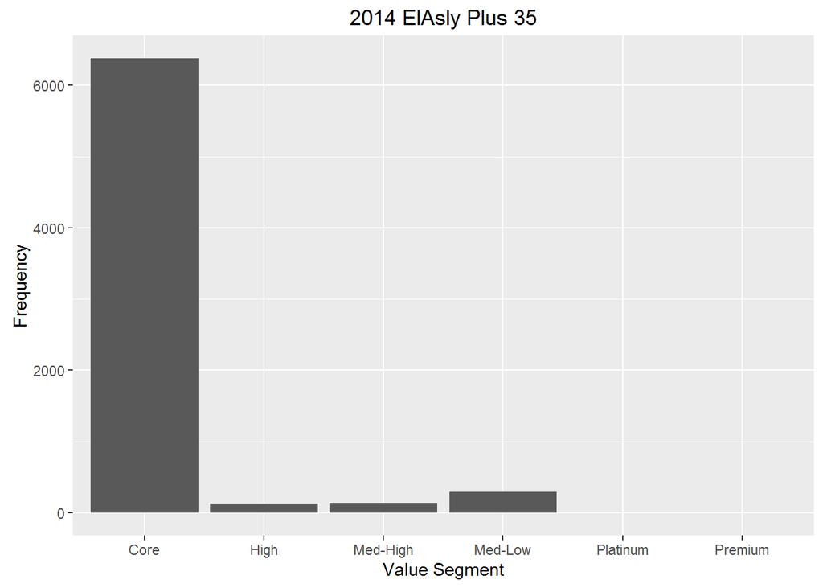

```r
vs_frequencies %>% ggplot(aes(x = VALUE_SEGMENT, y = VS_frequency)) + geom_bar(stat='identity') +
labs(title = "2014 ElAsly Plus 35", x = "Value Segment", y = "Frequency")
```

#### Red 150

```r
vs_frequencies <- contractRefDf %>% filter(RATE_PLAN == "Red 150", VALUE_SEGMENT != "N/A") %>% group_by(VALUE_SEGMENT) %>% summarise(VS_frequency = length(CONTRACT_KEY)) %>% arrange(desc(VS_frequency))
vs_frequencies
```

```
## Source: local data frame [4 x 2]
##
##   VALUE_SEGMENT VS_frequency
##          (fctr)        (int)
## 1          High         5092
## 2       Premium          216
## 3      Med-High           11
## 4      Platinum            5
```

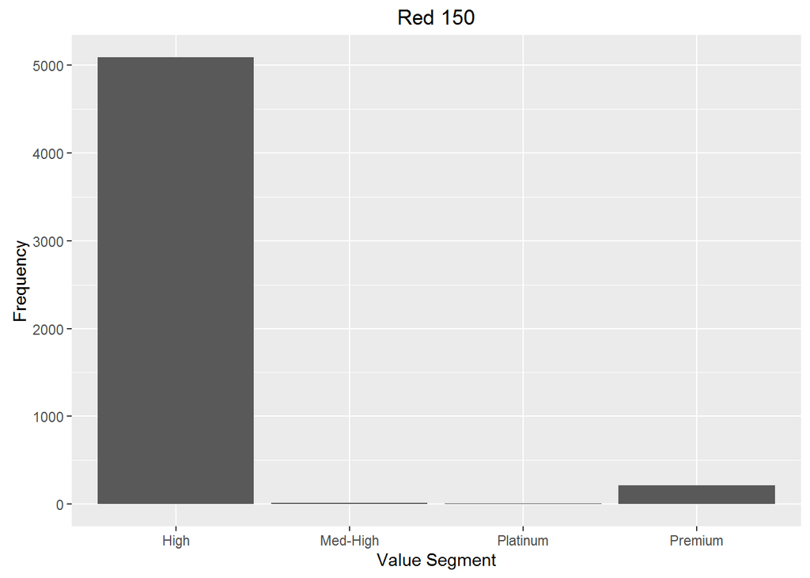

```r
vs_frequencies %>% ggplot(aes(x = VALUE_SEGMENT, y = VS_frequency)) + geom_bar(stat='identity') +
labs(title = "Red 150", x = "Value Segment", y = "Frequency")
```

It is clear that there is a strong relation between the `RATE_PLAN` and the `VALUE_SEGMENT`.

## 32- Cleaning the “N/A” values from the `VALUE_SEGMENT` and adding it to the predictions (Tony)

Let’s infer the “N/A” values of the `VALUE_SEGMENT` through its relation with the `RATE_PLAN` by replacing the `VALUE_SEGMENT` having an “N/A” value with the dominant `VALUE_SEGMENT` value corresponding to the same `RATE_PLAN`. If it’s still an “N/A” value, then take the second dominant one.

```r
dominant_value_segment <- function(rate_plan){
    vs_frequencies <- contractRefDf %>% filter(RATE_PLAN == rate_plan, VALUE_SEGMENT != "N/A") %>% group_by(VALUE_SEGMENT) %>% summarise(VS_frequency = length(CONTRACT_KEY)) %>% arrange(desc(VS_frequency))
    result <- vs_frequencies$VALUE_SEGMENT %>% first
    return(result)
}

contractRefDf$VALUE_SEGMENT[contractRefDf$VALUE_SEGMENT == "N/A"] <- dominant_value_segment(contractRefDf$RATE_PLAN)
```

Let’s see the new distribution of the `VALUE_SEGMENT` after getting rid of the “N/A” values.

```r
vs_frequencies <- contractRefDf %>% group_by(VALUE_SEGMENT) %>% summarise(VS_frequency = length(CONTRACT_KEY)) %>% arrange(desc(VS_frequency))
vs_frequencies
```

```
## Source: local data frame [6 x 2]
##
##   VALUE_SEGMENT VS_frequency
##          (fctr)        (int)
## 1          Core        56206
## 2          High        21666
## 3       Med-Low        12992
## 4      Med-High        12577
## 5       Premium         4157
## 6      Platinum          145
```

Let’s plot the result showing the frequencies where the X-Axis is for the `VALUE_SEGMENT` and the Y-Axis is for the corresponding frequency `VS_frequency`:

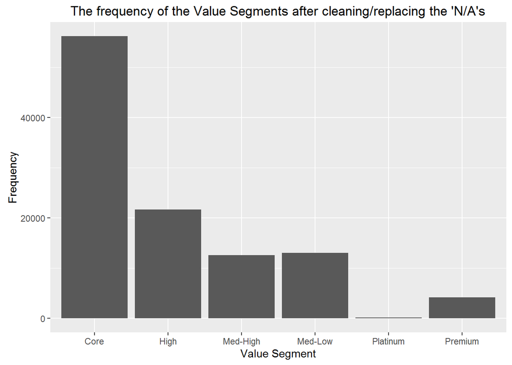

```r
vs_frequencies %>% ggplot(aes(x = VALUE_SEGMENT, y = VS_frequency)) + geom_bar(stat='identity') +
labs(title = "The frequency of the Value Segments after cleaning/replacing the 'N/A's", x = "Value Segment", y = "Frequency")
```

As we can see, almost half of the customers have a `VALUE_SEGMENT` of `Core` which is the dominant one.

Adding the `VALUE_SEGMENT` to the predicitons now yields a score of `0.63465`, which is not an improvement.

## 33- Analysing and extracting new features from `RATE_PLAN` and adding it to the predictions - Trial 2 (Tony)

Let’s try to extract the monetary value from the `RATE_PLAN` and then include it in the predictions, in a new column/attribute `RATE_PLAN_VALUE`.

First, let’s remove the year value:

```r
contractRefDf <- contractRefDf %>% mutate(RATE_PLAN_VALUE = gsub("[2][0][0-9][0-9] ", "", contractRefDf$RATE_PLAN))
```

Next, let’s remove the GBs size of the plan:

```r
contractRefDf$RATE_PLAN_VALUE <- gsub(" [0-9]+(\\.[0-9]*)* GB", "", contractRefDf$RATE_PLAN_VALUE)
```

Now, any numerical value existing in the `RATE_PLAN` is the monetary value we want. So let’s remove any other parts and just keep the number(s):

```r
contractRefDf$RATE_PLAN_VALUE <- gsub(" [a-zA-Z]+", "", contractRefDf$RATE_PLAN_VALUE)
contractRefDf$RATE_PLAN_VALUE <- gsub("[a-zA-Z]+ ", "", contractRefDf$RATE_PLAN_VALUE)
# contractRefDf$RATE_PLAN_VALUE <- as.factor(contractRefDf$RATE_PLAN_VALUE)
```

Let’s see the different levels in the `RATE_PLAN_VALUE` how they look:

```r
contractRefDf$RATE_PLAN_VALUE %>% unique
```

```
##  [1] "50"         "40"         "250"        "300"        "35"
##  [6] "150"        "100"        "30"         "40 50"      "POS"
## [11] "Enterprise" "110"        "Ostooly"    "Arabeety"   "60"
## [16] "75"         "25"         "350"        "Unified"    "VPN"
## [21] "20 50"      "60 100"     "60 150"     "40 100"     "80 100"
## [26] "Employee"   "65"         "20"         "Business"   "500"
## [31] "Flex"       "80 150"     "RED"        "Upper"      "550"
## [36] "200"        "90 100"     "90"         "TE"         "Data"
## [41] "59"         "Tailored"   "400"        "V2V"        "80"
## [46] "45 100"     "45"         "5"          "Business."  "Vodafone"
## [51] "80 200"     "MAC"        "90 150"     "120"        " 75"
## [56] "Super"      "499"        "199"        "New"        "VIP"
## [61] "Browser"    "399"
```

Let’s check now the number of `RATE_PLAN_VALUE` levels:

```r
contractRefDf$RATE_PLAN_VALUE %>% unique %>% length
```

```
## [1] 62
```

Adding the `RATE_PLAN_VALUE` to the predicitions yields a score of `0.64236`.

## 34- Adding the approaches of the 2 trials of extracting features from the `RATE_PLAN` in the `contractRefDf` (Tony)

```r
contractRefDfTemp <- contractRefDf
```

So building on 33 and applying what was done in 22 by updating the `RATE_PLAN` as follows: Discarding the year value from the `RATE_PLAN` in addition to the other numerical values such as the amount of GBs and the rate plan monetary value.

```r
contractRefDfTemp$RATE_PLAN <- gsub("[2][0][0-9][0-9] ", "", contractRefDfTemp$RATE_PLAN)
contractRefDfTemp$RATE_PLAN <- gsub(" [0-9]+(\\.[0-9]*)* GB", "", contractRefDfTemp$RATE_PLAN)
contractRefDfTemp$RATE_PLAN <- gsub(" [0-9]+", "", contractRefDfTemp$RATE_PLAN)
contractRefDfTemp$RATE_PLAN <- as.factor(contractRefDfTemp$RATE_PLAN)
```

So adding both the updated `RATE_PLAN` and the `RATE_PLAN_VALUE` (calculated in 33) together to the predictions, we obtain a minimum score of `0.50000`.

## 35- Analysing and extracting new features from `RATE_PLAN` and adding it to the predictions - Trial 3 (Tony)

Building on 33 (Trial 2), let’s proceed to have a `RATE_PLAN_VALUE` for all the rate plans we have. Some of the `RATE_PLAN_VALUE` values have a combination of plans. Hence, at this stage for such examples, the `RATE_PLAN_VALUE` might have two monetary values; such as ‘30 150’. So let’s extract the numerical values out and get their mean. The single values will remain as they are and the non numerical values (the rate plans that didn’t contain any monetary value such as `Enterprise Shared Data Bundle`) will have their `RATE_PLAN_VALUE` as NAs.

```r
contractRefDf$RATE_PLAN_VALUE <- contractRefDf$RATE_PLAN_VALUE %>% sapply(function(x) x %>% strsplit(" ") %>% sapply(function(y) as.numeric(y)) %>% mean)
contractRefDf$RATE_PLAN_VALUE <- as.factor(contractRefDf$RATE_PLAN_VALUE)
```

Let’s see the different levels in the `RATE_PLAN_VALUE` how they look:

```r
contractRefDf$RATE_PLAN_VALUE %>% unique
```

```
##  [1] 50   40   250  300  35   150  100  30   45   <NA> 110  60   75   25
## [15] 350  80   105  70   90   65   20   500  115  550  200  95   59   400
## [29] 72.5 5    140  120  499  199  399
## 34 Levels: 5 20 25 30 35 40 45 50 59 60 65 70 72.5 75 80 90 95 100 ... 550
```

Let’s check the number of levels now:

```r
contractRefDf$RATE_PLAN_VALUE %>% unique %>% length
```

```
## [1] 35
```

Let’s check now the most frequent rate plan values we have so far:

```r
contractRefDf %>% filter(!is.na(RATE_PLAN_VALUE)) %>% group_by(RATE_PLAN_VALUE) %>% summarise(RPV_frequency = length(CONTRACT_KEY)) %>% arrange(desc(RPV_frequency))
```

```
## Source: local data frame [34 x 2]
##
##    RATE_PLAN_VALUE RPV_frequency
##             (fctr)         (int)
## 1               35         15976
## 2              150         12399
## 3               30         12192
## 4               50          8319
## 5               45          5662
## 6               25          2428
## 7              250          2341
## 8              100          1989
## 9              300          1853
## 10              60          1651
## ..             ...           ...
```

Let’s now see the relation between the `RATE_PLAN_VALUE` and the average data usage of the customers:

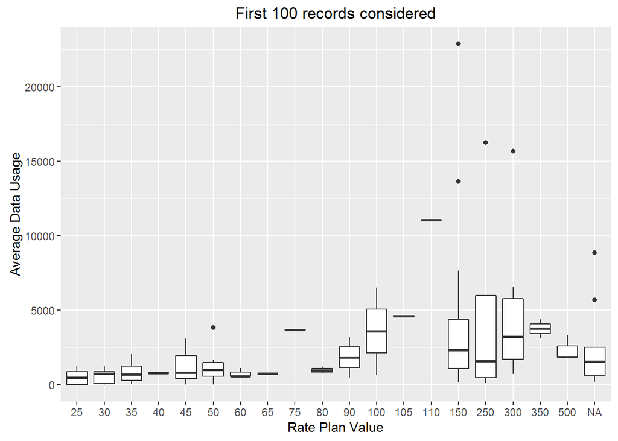

```r
trainDf <- trainDf %>% rowwise() %>% mutate(mean_usage = mean(c(X206_USAGE,X207_USAGE,X208_USAGE,X209_USAGE,X210_USAGE)))
testDf <- testDf %>% rowwise() %>% mutate(mean_usage = mean(c(X206_USAGE,X207_USAGE,X208_USAGE,X209_USAGE,X210_USAGE)))
trainDf <- merge(trainDf, contractRefDf, by = "CONTRACT_KEY")
testDf <- merge(testDf, contractRefDf, by = "CONTRACT_KEY")

ggplot(trainDf %>% head(100), aes(x = RATE_PLAN_VALUE, y = mean_usage)) + geom_boxplot() +
labs(title = "First 100 records considered", x = "Rate Plan Value", y = "Average Data Usage")
```

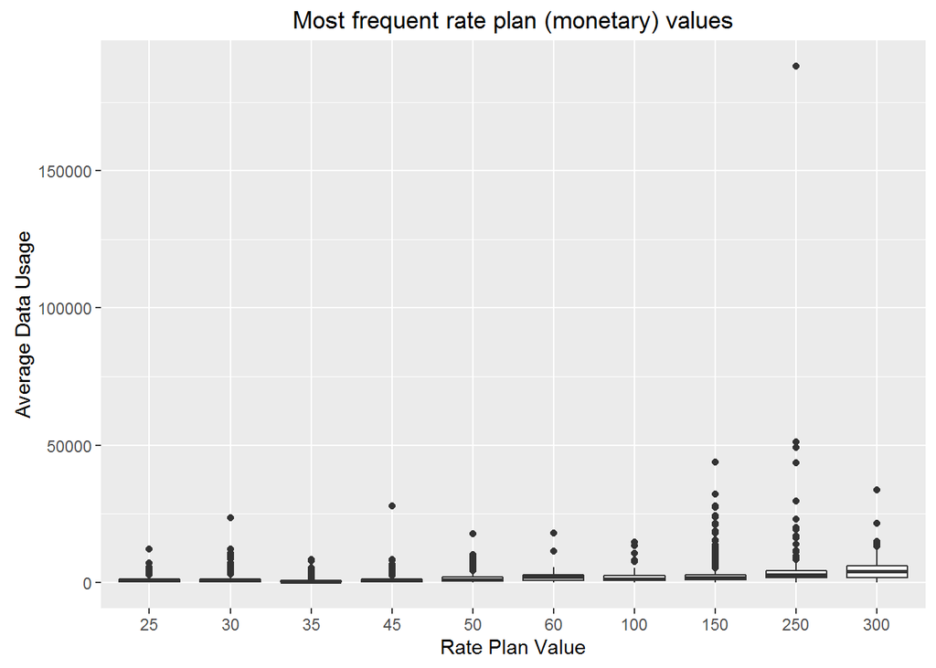

```r
ggplot(trainDf %>% filter(RATE_PLAN_VALUE == c(25, 30, 35, 45, 50, 60, 100, 150, 250, 300)), aes(x = RATE_PLAN_VALUE, y = mean_usage)) + geom_boxplot() +
labs(title = "Most frequent rate plan (monetary) values", x = "Rate Plan Value", y = "Average Data Usage")
```

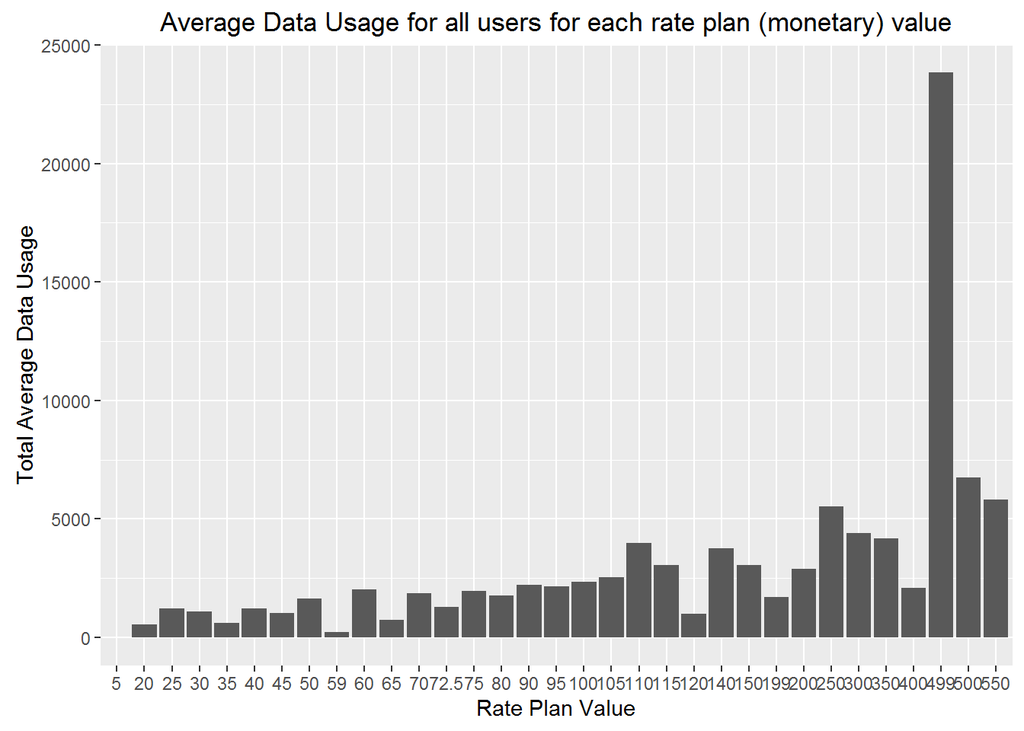

```r
p <- trainDf %>% filter(!is.na(RATE_PLAN_VALUE)) %>% group_by(RATE_PLAN_VALUE) %>% summarise(total_mean_usage = mean(mean_usage))

p %>% ggplot(aes(x = RATE_PLAN_VALUE, y = total_mean_usage)) + geom_bar(stat='identity') +
labs(title = "Average Data Usage for all users for each rate plan (monetary) value", x = "Rate Plan Value", y = "Total Average Data Usage")
```

Let’s have a more generalized feature for the average data usage to help us spot the relation between the `RATE_PLAN_VALUE` and the amount of data usage. So let’s round the calculated `mean_usage` to the nearest 100 MB:

```r
trainDf <- trainDf %>% mutate(mean_usage_app = round(mean_usage/100)*100)
testDf <- testDf %>% mutate(mean_usage_app = round(mean_usage/100)*100)
```

Let’s see the number of levels for the approximated mean usage:

```r
trainDf$mean_usage_app %>% unique %>% length
```

```
## [1] 401
```

Let’s see the most frequent value from the distribution of those approximated average data usage values in the train dataset:

```r
trainDf %>% group_by(mean_usage_app) %>% summarise(USAGE_frequency = length(CONTRACT_KEY)) %>% arrange(desc(USAGE_frequency))
```

```
## Source: local data frame [401 x 2]
##
##    mean_usage_app USAGE_frequency
##             (dbl)           (int)
## 1               0           14998
## 2             200            5241
## 3             100            4410
## 4             300            3748
## 5             400            2934
## 6             500            2504
## 7             600            2198
## 8             700            2149
## 9             800            2069
## 10            900            2019
## ..            ...             ...
```

As we can see, the most frequent value corresponds to a usage below `50 MB` (0), followed by `200 MB` and `100 MB`. Let’s check the relation of those frequent approximated average data usage values with the `RATE_PLAN_VALUE`:

### Below 50 MB (0):

```r
rpv_frequencies <- trainDf %>% filter(mean_usage_app == 0, !is.na(RATE_PLAN_VALUE)) %>% group_by(RATE_PLAN_VALUE) %>% summarise(RPV_frequency = length(CONTRACT_KEY)) %>% arrange(desc(RPV_frequency))
rpv_frequencies
```

```
## Source: local data frame [30 x 2]
##
##    RATE_PLAN_VALUE RPV_frequency
##             (fctr)         (int)
## 1               35          1141
## 2               30          1121
## 3               50           411
## 4               45           294
## 5              150           196
## 6                5           194
## 7               25           167
## 8               20           106
## 9               40           101
## 10              60            95
## ..             ...           ...
```

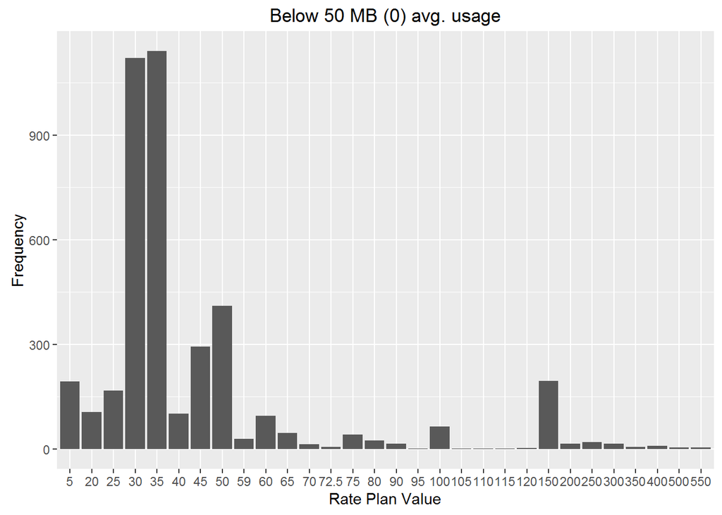

```r
rpv_frequencies %>% ggplot(aes(x = RATE_PLAN_VALUE, y = RPV_frequency)) + geom_bar(stat='identity') +
labs(title = "Below 50 MB (0) avg. usage", x = "Rate Plan Value", y = "Frequency")
```

As we can see, the dominant rate plan (monetary) values for the corresponding (< 50 MB [0] avg. usage) are the `30` and `35` ones. Both are quite close values. Hence, it’s showing a relation between the `RATE_PLAN_VALUE` and the corresponding average data usage.

### 200 MB:

```r
rpv_frequencies <- trainDf %>% filter(mean_usage_app == 200, !is.na(RATE_PLAN_VALUE)) %>% group_by(RATE_PLAN_VALUE) %>% summarise(RPV_frequency = length(CONTRACT_KEY)) %>% arrange(desc(RPV_frequency))
rpv_frequencies
```

```
## Source: local data frame [30 x 2]
##
##    RATE_PLAN_VALUE RPV_frequency
##             (fctr)         (int)
## 1               35          2156
## 2               30           488
## 3               45           335
## 4               50           266
## 5              150           253
## 6               65           106
## 7               40            82
## 8               25            77
## 9              100            46
## 10             250            38
## ..             ...           ...
```

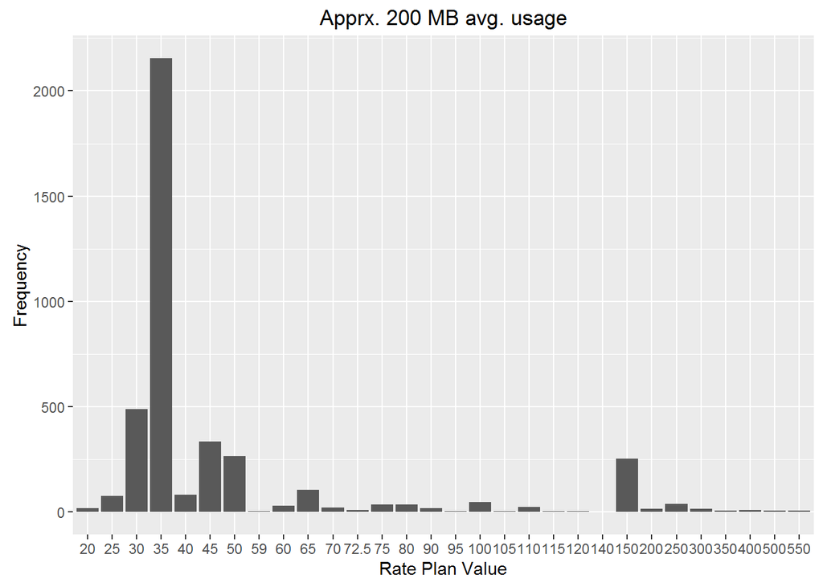

```r
rpv_frequencies %>% ggplot(aes(x = RATE_PLAN_VALUE, y = RPV_frequency)) + geom_bar(stat='identity') +
labs(title = "Apprx. 200 MB avg. usage", x = "Rate Plan Value", y = "Frequency")
```

As we can see, the dominant rate plan (monetary) values for the corresponding (apprx. 200 MB avg. usage) is `35`. Hence, it’s showing a relation between the `RATE_PLAN_VALUE` and the corresponding average data usage.

### 100 MB:

```r
rpv_frequencies <- trainDf %>% filter(mean_usage_app == 100, !is.na(RATE_PLAN_VALUE)) %>% group_by(RATE_PLAN_VALUE) %>% summarise(RPV_frequency = length(CONTRACT_KEY)) %>% arrange(desc(RPV_frequency))
rpv_frequencies
```

```
## Source: local data frame [29 x 2]
##
##    RATE_PLAN_VALUE RPV_frequency
##             (fctr)         (int)
## 1               35          1486
## 2               30           673
## 3               45           390
## 4               50           299
## 5              150           277
## 6               25           116
## 7               40            93
## 8               65            69
## 9              100            51
## 10              80            44
## ..             ...           ...
```

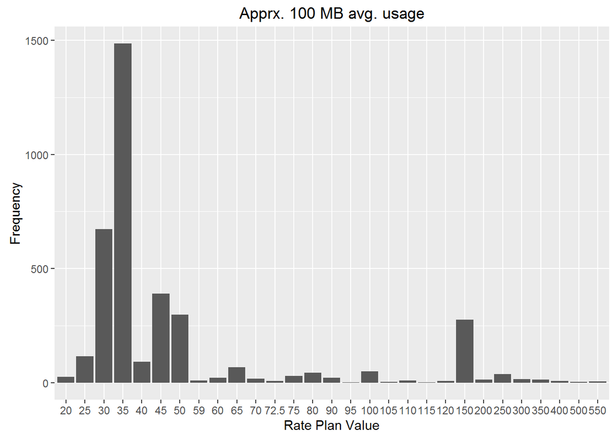

```r
rpv_frequencies %>% ggplot(aes(x = RATE_PLAN_VALUE, y = RPV_frequency)) + geom_bar(stat='identity') +
labs(title = "Apprx. 100 MB avg. usage", x = "Rate Plan Value", y = "Frequency")
```

As we can see, the dominant rate plan (monetary) values for the corresponding (apprx. 100 MB avg. usage) is `35`. Hence, it’s showing a relation between the `RATE_PLAN_VALUE` and the corresponding average data usage.

As we can see from all the previous calculations and data plotting, we can say that there’s a relation between the `RATE_PLAN_VALUE` and the data usage.

So let’s infer the missing `RATE_PLAN_VALUE` values (NAs) from this relation; where the missing `rate_plan_value` shall be replaced by the most dominant `RATE_PLAN_VALUE` occuring with the same approximated average data usage of corresponding user:

```r
dominant_rate_plan_value_train <- function(usage_app){
  rpv_frequencies <- trainDf %>% filter(mean_usage_app == usage_app, !is.na(RATE_PLAN_VALUE)) %>% group_by(RATE_PLAN_VALUE) %>% summarise(RPV_frequency = length(CONTRACT_KEY)) %>% arrange(desc(RPV_frequency))
  result <- rpv_frequencies$RATE_PLAN_VALUE %>% first
  return(result)
}

dominant_rate_plan_value_test <- function(usage_app){
  rpv_frequencies <- testDf %>% filter(mean_usage_app == usage_app, !is.na(RATE_PLAN_VALUE)) %>% group_by(RATE_PLAN_VALUE) %>% summarise(RPV_frequency = length(CONTRACT_KEY)) %>% arrange(desc(RPV_frequency))
  result <- rpv_frequencies$RATE_PLAN_VALUE %>% first
  return(result)
}

trainDf$RATE_PLAN_VALUE[is.na(trainDf$RATE_PLAN_VALUE)] <- dominant_rate_plan_value_train(trainDf$mean_usage_app)
testDf$RATE_PLAN_VALUE[is.na(testDf$RATE_PLAN_VALUE)] <- dominant_rate_plan_value_test(testDf$mean_usage_app)
```

Adding the calculated `RATE_PLAN_VALUE` to the predictions yields a score of `0.65238`.

## – MLP with different model parameters (Mimi & Amir)

The MLP that scored the highest score so far `0.70333` (in step 26) had a learning rate of `0.3`. When building the model with a lesser learning rate of `0.2`, a decreased score of `0.70168` was obtained. The reason for this could be that the lesser learning rate caused the network to reach a local minimum when training, hence the neural network was not trained in the optimal way.

## – Ensemble Kaggle Submissions (Mimi)

We tried to improve our score by ensembling some of our best submissions. We calculted the correlation between submissions using this pythong script which is viewable in the Kaggle-Ensemble-Guide repo correlations.py. When choosing high-correlated submissions the score changed slightly (which made sense). An example of that is that the score changed from `0.70333` to `0.70359` (best score so far) when we ensembled the submissions 25 & 26 with weights 1 and 3 respectively using the voting approach described here kaggle_vote.py.

We also tried to ensmeble low-correlated submissions of the two approaches in `26` and `36` and and this gave a decreased score of `0.68192`.

# – Local CV on our final features (Amir)

To recap our previous work, we have added many features that have increased our kaggle score, and temporarily added some features that unfortunately did not and ultimately removed them. In some of the intermediate steps, we have relied on the kaggle scoring to determine the usefulness of features, as performing cross validation in every minor step was time-consuming and unpractical. Working throughout a long period of time permiited us to make use of a large number of submissions, so CV was done in some of the steps only. Using the chosen final features, I have run a one time 5-fold cross validation on my local machine, using these features and 4 diferrent classifiers:

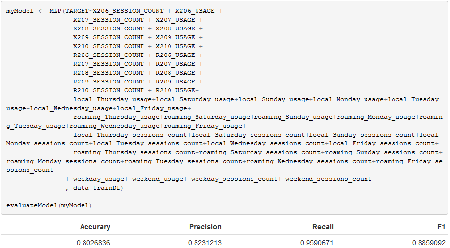

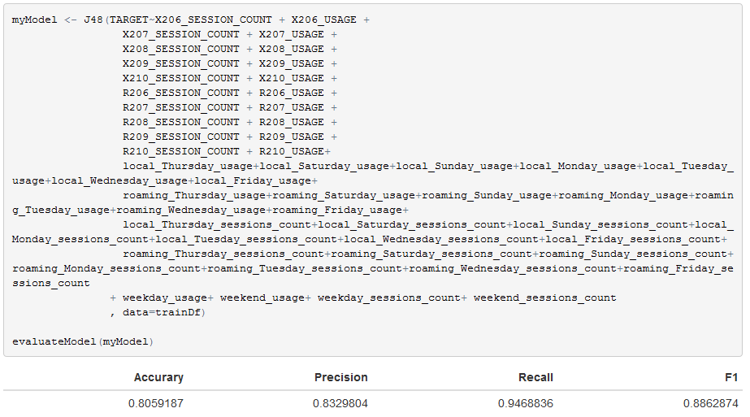

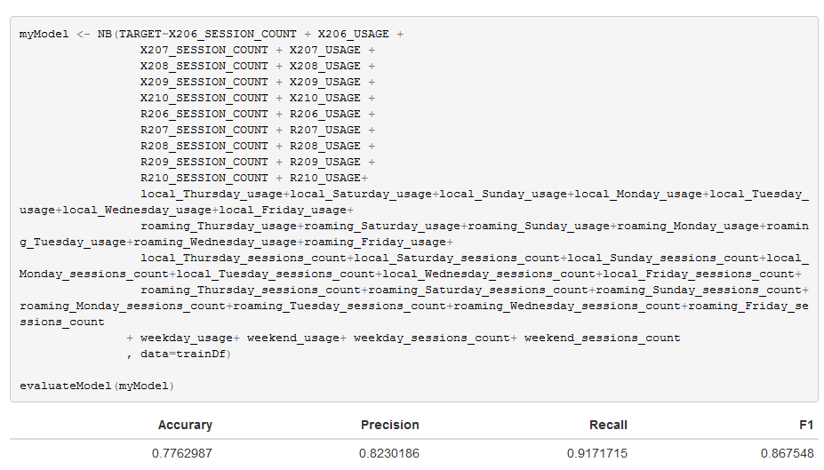

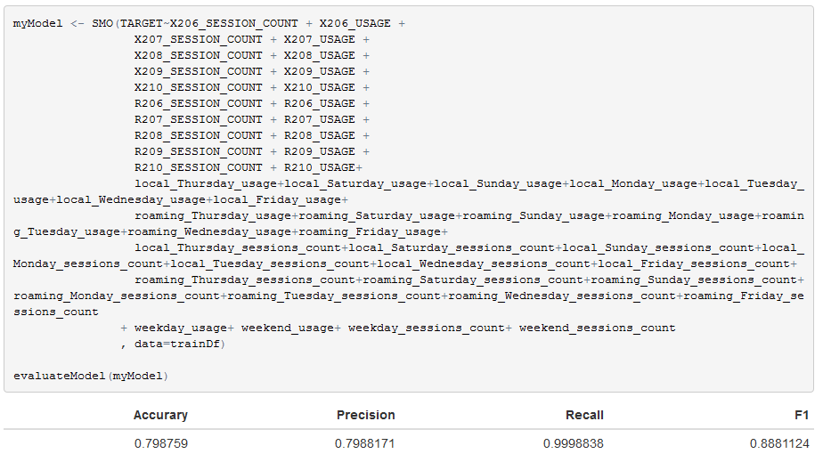

Same as when using the initial features, the SMO classifier achieves the highest F1 score due to its almost perfect recall score. Our experience with CV on the initial features indicates that this is probably due to overfitting This is confirmed the fact that the `SMO` classifier scored the least scores on kaggle among the rest of the classifiers. Also, we note that that our chosen MLP classifier scored only the second best precision after the J48 classifier. But, when trying a submission using our final features, a significantly decreased score of `0.59285` was obtained, which is evidence that the higher CV kaggle scores is probably due to overfitting as well. Generally, these discrepancies could be attributed to using one-time 5-fold CV only (due to computational time constraints). As a results, we made use of evaluation results from Microsoft Azure server as well for better insights.

# – CrossValidation between different models on Azure server (Mimi)

At different steps, we carried on cross validation using our chosen features on some models on Microsoft Azure. It was unpractical to fully rely on local CV at each minor modification due to the exceedingly long computational times. Below is a demonstration of Azure CV results using 4 sets of features as described:

## Cross validation for the first train columns:

This is using all the original features from the original train dataset and before integrating with roaming and daily data).

```r
summary <- crossValidation %>% group_by(Model) %>% summarise(accuracy = mean(Accuracy), precision = mean(Precision),recall = mean(Recall), F.Score = mean(F.Score), AUC = mean(AUC))
summary %>% kable
```

| Model | accuracy | precision | recall | F.Score | AUC |
| --- | --- | --- | --- | --- | --- |
| Bayes Point | 0.7346481 | 0.5179601 | 0.0467268 | 0.0855359 | 0.6793212 |
| Binary Neural Network | 0.7325643 | 0.4597906 | 0.0411947 | 0.0749491 | 0.6709569 |
| Decision Forest Classifier | 0.7437830 | 0.5328407 | 0.2030223 | 0.2936428 | 0.7423799 |
| Decision Jungle Classifier | 0.7303949 | 0.4478821 | 0.2102188 | 0.2859521 | 0.6898601 |
| FastTree (Boosted Trees) Classification | 0.7326522 | 0.0000000 | 0.0000000 | 0.0000000 | 0.7025295 |
| Local Deep SVM (LDSVM) | 0.7317354 | 0.4548433 | 0.0910134 | 0.1496510 | 0.6762043 |
| SVM (Pegasos-Linear) | 0.7343150 | 0.4951100 | 0.0606894 | 0.1079852 | 0.6864385 |

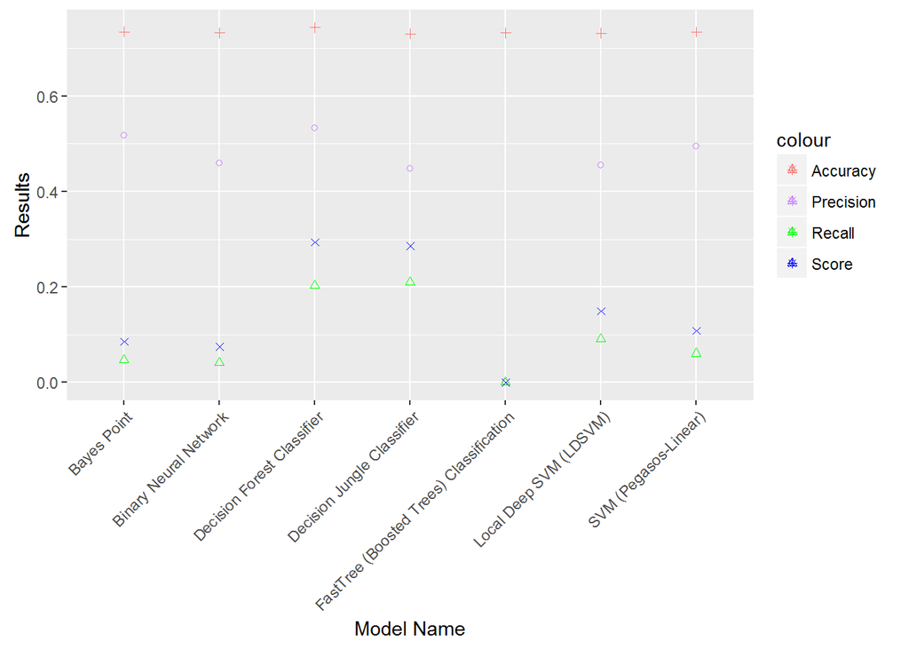

```r
NN_percisions <- c(summary[2,3]$precision)
DF_precisions <- c(summary[3,3]$precision)
SVM_precisions <- c(summary[7,3]$precision)
NN_acc <- c(summary[2,2]$accuracy)
DF_acc <- c(summary[3,2]$accuracy)
SVM_acc <- c(summary[7,2]$accuracy)

ggplot(summary, aes(Model)) +
  geom_point(aes(y = precision, colour ='Precision'), size=1.5, group = 1, shape=1) +
  geom_point(aes(y = recall, colour = 'Recall'), size= 1.5, group = 1, shape=2)+
  geom_point(aes(y = accuracy, colour = 'Accuracy'), size= 1.5, group = 1, shape=3)+
  geom_point(aes(y = F.Score, colour = 'Score'), size= 1.5, group = 1, shape=4)+
  xlab("Model Name")+ylab("Results")  +
  scale_colour_manual(values=c("#F57670","#C680FC","GREEN","BLUE"))+
  #scale_shape_discrete(solid=T, legend=F) +
  theme(axis.text.x = element_text(angle = 45, hjust = 1))
```

## Cross validation for the model after extracing the roaming features

As illustrated in script & step `13`.

```r
summary <- crossValidation %>% group_by(Model) %>% summarise(accuracy = mean(Accuracy), precision = mean(Precision),recall = mean(Recall), F.Score = mean(F.Score), AUC = mean(AUC))
summary %>% kable
```

| Model | accuracy | precision | recall | F.Score | AUC |
| --- | --- | --- | --- | --- | --- |
| Bayes Point | 0.7348142 | 0.4976370 | 0.0741455 | 0.1289134 | 0.6786810 |
| Binary Neural Network | 0.7370411 | 0.5544772 | 0.0678571 | 0.1202245 | 0.7166437 |
| Decision Forest Classifier | 0.7447773 | 0.5439843 | 0.1953528 | 0.2872460 | 0.7430288 |
| Decision Jungle Classifier | 0.7322817 | 0.4576892 | 0.2093885 | 0.2870935 | 0.6894177 |
| FastTree (Boosted Trees) Classification | 0.7326522 | 0.0000000 | 0.0000000 | 0.0000000 | 0.7142510 |
| Local Deep SVM (LDSVM) | 0.7382626 | 0.5484349 | 0.1101179 | 0.1781303 | 0.6696837 |
| SVM (Pegasos-Linear) | 0.7353470 | 0.5391224 | 0.0476045 | 0.0868643 | 0.6563819 |

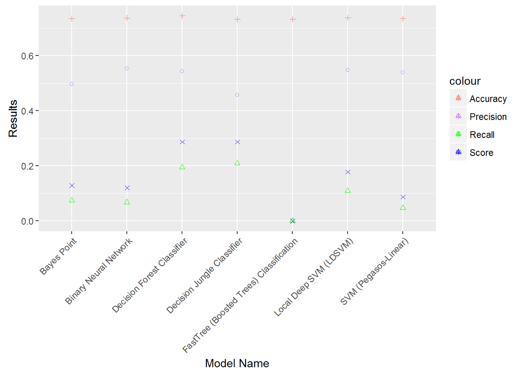

```r
NN_percisions <- c(NN_percisions,summary[2,3]$precision)
DF_precisions <- c(DF_precisions,summary[3,3]$precision)
SVM_precisions <- c(SVM_precisions,summary[7,3]$precision)
NN_acc <- c(NN_acc,summary[2,2]$accuracy)
DF_acc <- c(DF_acc,summary[3,2]$accuracy)
SVM_acc <- c(SVM_acc,summary[7,2]$accuracy)


ggplot(summary, aes(Model)) +
  geom_point(aes(y = precision, colour ='Precision'), size=1.5, group = 1, shape=1) +
  geom_point(aes(y = recall, colour = 'Recall'), size= 1.5, group = 1, shape=2)+
  geom_point(aes(y = accuracy, colour = 'Accuracy'), size= 1.5, group = 1, shape=3)+
  geom_point(aes(y = F.Score, colour = 'Score'), size= 1.5, group = 1, shape=4)+
  xlab("Model Name")+ylab("Results")  +
  scale_colour_manual(values=c("#F57670","#C680FC","GREEN","BLUE"))+
  #scale_shape_discrete(solid=T, legend=F) +
  theme(axis.text.x = element_text(angle = 45, hjust = 1))
```

Cross validation for the model after extracting the daily features.: (Script & Step 25)

```r
summary <- crossValidation %>% group_by(Model) %>% summarise(accuracy = mean(Accuracy), precision = mean(Precision),recall = mean(Recall), F.Score = mean(F.Score), AUC = mean(AUC))
summary %>% kable
```

| Model | accuracy | precision | recall | F.Score | AUC |
| --- | --- | --- | --- | --- | --- |
| Bayes Point | 0.7339793 | 0.4891014 | 0.0560079 | 0.1003416 | 0.6798530 |
| Binary Neural Network | 0.7362806 | 0.6254634 | 0.0366768 | 0.0688901 | 0.7338194 |
| Decision Forest Classifier | 0.7431217 | 0.5351113 | 0.1866202 | 0.2764525 | 0.7413275 |
| Decision Jungle Classifier | 0.7323808 | 0.4584608 | 0.2062698 | 0.2844771 | 0.6924104 |
| FastTree (Boosted Trees) Classification | 0.7326522 | 0.0000000 | 0.0000000 | 0.0000000 | 0.7029698 |
| Local Deep SVM (LDSVM) | 0.7369052 | 0.5065202 | 0.1166120 | 0.1892887 | 0.7201698 |
| SVM (Pegasos-Linear) | 0.7349026 | 0.5169958 | 0.0504371 | 0.0917080 | 0.6982722 |

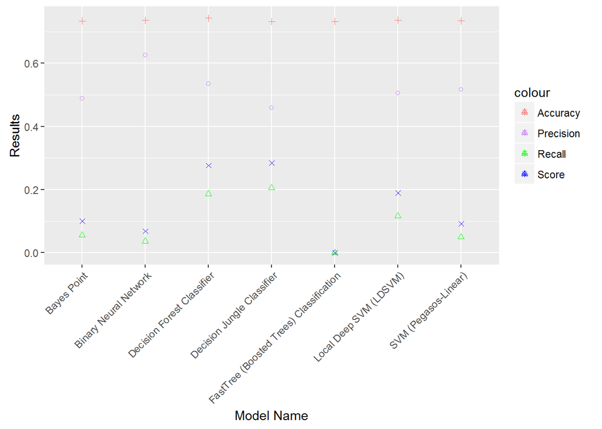

```r
NN_percisions <- c(NN_percisions,summary[2,3]$precision)
DF_precisions <- c(DF_precisions,summary[3,3]$precision)
SVM_precisions <- c(SVM_precisions,summary[7,3]$precision)
NN_acc <- c(NN_acc,summary[2,2]$accuracy)
DF_acc <- c(DF_acc,summary[3,2]$accuracy)
SVM_acc <- c(SVM_acc,summary[7,2]$accuracy)

ggplot(summary, aes(Model)) +
  geom_point(aes(y = precision, colour ='Precision'), size=1.5, group = 1, shape=1) +
  geom_point(aes(y = recall, colour = 'Recall'), size= 1.5, group = 1, shape=2)+
  geom_point(aes(y = accuracy, colour = 'Accuracy'), size= 1.5, group = 1, shape=3)+
  geom_point(aes(y = F.Score, colour = 'Score'), size= 1.5, group = 1, shape=4)+
  xlab("Model Name")+ylab("Results")  +
  scale_colour_manual(values=c("#F57670","#C680FC","GREEN","BLUE"))+
  #scale_shape_discrete(solid=T, legend=F) +
  theme(axis.text.x = element_text(angle = 45, hjust = 1))
```

## Cross validation for the model after adding weekday and weekend features

As illustrated in step and script `26`.

```r
summary <- crossValidation %>% group_by(Model) %>% summarise(accuracy = mean(Accuracy), precision = mean(Precision),recall = mean(Recall), F.Score = mean(F.Score), AUC = mean(AUC))
summary %>% kable
```

| Model | accuracy | precision | recall | F.Score | AUC |
| --- | --- | --- | --- | --- | --- |
| Bayes Point | 0.7340025 | 0.4891093 | 0.0572228 | 0.1022962 | 0.6798825 |
| Binary Neural Network | 0.8008275 | 0.6908027 | 0.0205102 | 0.0394518 | 0.7927399 |
| Decision Forest Classifier | 0.7433788 | 0.5362083 | 0.1878884 | 0.2779287 | 0.7418678 |
| Decision Jungle Classifier | 0.7299323 | 0.4453893 | 0.2000224 | 0.2757005 | 0.6902987 |
| FastTree (Boosted Trees) Classification | 0.7326522 | 0.0000000 | 0.0000000 | 0.0000000 | 0.7031999 |
| Local Deep SVM (LDSVM) | 0.7364555 | 0.5037323 | 0.1124141 | 0.1827079 | 0.7093754 |
| SVM (Pegasos-Linear) | 0.7351435 | 0.5218912 | 0.0524214 | 0.0950926 | 0.7020996 |

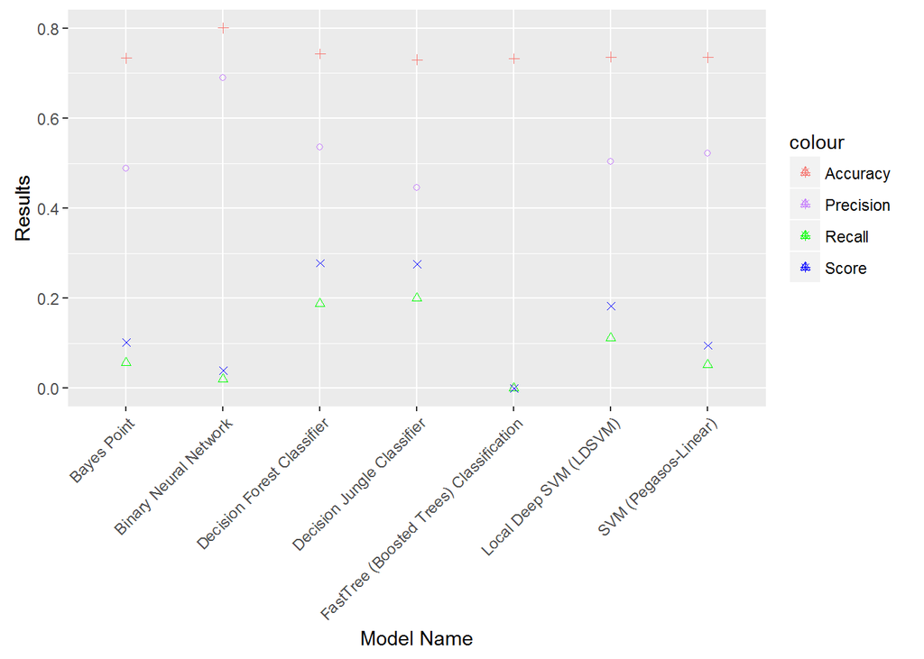

```r
NN_percisions <- c(NN_percisions,summary[2,3]$precision)
DF_precisions <- c(DF_precisions,summary[3,3]$precision)
SVM_precisions <- c(SVM_precisions,summary[7,3]$precision)
NN_acc <- c(NN_acc,summary[2,2]$accuracy)
DF_acc <- c(DF_acc,summary[3,2]$accuracy)
SVM_acc <- c(SVM_acc,summary[7,2]$accuracy)

ggplot(summary, aes(Model)) +
  geom_point(aes(y = precision, colour ='Precision'), size=1.5, group = 1, shape=1) +
  geom_point(aes(y = recall, colour = 'Recall'), size= 1.5, group = 1, shape=2)+
  geom_point(aes(y = accuracy, colour = 'Accuracy'), size= 1.5, group = 1, shape=3)+
  geom_point(aes(y = F.Score, colour = 'Score'), size= 1.5, group = 1, shape=4)+
  xlab("Model Name")+ylab("Results")  +
  scale_colour_manual(values=c("#F57670","#C680FC","GREEN","BLUE"))+
  #scale_shape_discrete(solid=T, legend=F) +
  theme(axis.text.x = element_text(angle = 45, hjust = 1))
```

Note that the Neural Network has the most accuracy. However we need to check the precision to get a better indicator of the better classifier.

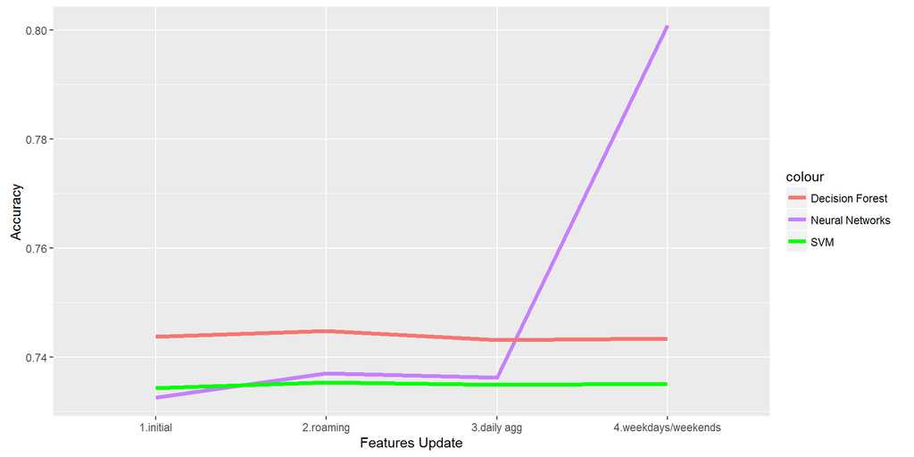

```r
a <- c("1.initial","2.roaming","3.daily agg","4.weekdays/weekends")
df <- data.frame(updates = a, NN = NN_acc, DF =  DF_acc, SVM = SVM_acc)
ggplot(df, aes(updates)) +
  geom_line(aes(y = NN, colour = "Neural Networks"), size=1.5, group = 1) +
  geom_line(aes(y = DF, colour = "Decision Forest"), size=1.5, group = 1) +
  geom_line(aes(y = SVM, colour = "SVM"), size=1.5, group = 1) +
  xlab("Features Update")+ylab("Accuracy")  +
  scale_colour_manual(values=c("#F57670","#C680FC","#00FF00"))
```

We can see that the precision of Neural Networks increases as we add our new features and adding them achieves the best increase in precision among the other classifiers.

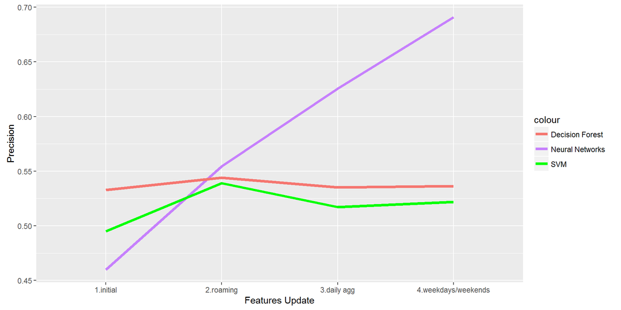

```r
df <- data.frame(updates = a, NN = NN_percisions, DF =  DF_precisions, SVM = SVM_precisions)
ggplot(df, aes(updates)) +
  geom_line(aes(y = NN, colour = "Neural Networks"), size=1.5, group = 1) +
  geom_line(aes(y = DF, colour = "Decision Forest"), size=1.5, group = 1) +
  geom_line(aes(y = SVM, colour = "SVM"), size=1.5, group = 1) +
  xlab("Features Update")+ylab("Precision")  +
  scale_colour_manual(values=c("#F57670","#C680FC","#00FF00"))
```

## Notes on model parameter selection in Azure

For Random forest classifiers we set the the number of tree in the range of (64-128) according to this [article](https://www.researchgate.net/publication/230766603_How_Many_Trees_in_a_Random_Forest) . The goal from this was to balance between the performance of results and the computational time in training.

In general, when we used Azure classsifers We used range parameters, to give the classifier a better chance at calculating the optimal parameters.

## Evaluation by splitting data on Azure server (Mimi)

In addition to the CV we did on Azure server, we did another evaluation on Azure of the neural network model by splitting the train data into stratified samples where the data to be trained is 70% of the whole data.

```r
evalModel <- read.csv('CrossValidationsDataFramesAzure/evaluateModel.csv')
evalModel %>% kable
```

| Accuracy | Precision | Recall | F.Score | AUC | Average.Log.Loss | Training.Log.Loss |
| --- | --- | --- | --- | --- | --- | --- |
| 0.8095996 | 0.6626826 | 0.1095981 | 0.188089 | 0.7978826 | 0.4075368 | 18.83371 |

# Conclusion (Amir)

Throughout the whole course of our work, we have utilized different features. We had an initial thought that the usage only would be of importance. However, the session count data proved useful as well and factoring it caused better predictions. Although the roaming data was covering only a small percentage of the users in both datasets, our predictions were improved by adding features extracted from it. We believe that the relatively small availability of roaming data is attributed to the fact that using roaming mobile data is indeed relatively rare compared to local data. Last but not least, features extracted from the daily aggregate data of the last month slightly improved our predictions as well. It was impractical to add features representing the usage and session count for each of the 30 days. So, instead, we added features representing each of the seven days of the week. Last but not least, adding features representing usage and session count for the weekends and weekdays slightly improved our results. This points to a relation between user behaviour and the day being a weekday or weekend.